# SQ 009_Confidence_Intervals

## Shared Qs (009_Confidence_Intervals)

#### Question

1. A sample of size $n=200$ was taken from an unknown population. **Identify the correct histogram and describe the shape.** Note, the bucket size is 1.

   | 2.92 | 3.76 | 2.28 | 2.36 | 7.45 | 6.47 | 0.56 | 7.14 | 6.63 | 6.92 |
   | --- | --- | --- | --- | --- | --- | --- | --- | --- | --- |
   | 0.87 | 2.06 | 2.34 | 8.19 | 6.97 | 3.54 | 0.69 | 3.15 | 1.25 | 8.32 |
   | 6.59 | 3.34 | 7.84 | 1.38 | 5.72 | 2.88 | 4.92 | 5.65 | 7.71 | 4.02 |
   | 4.58 | 1.80 | 9.37 | 3.58 | 4.94 | 5.01 | 7.75 | 2.83 | 1.56 | 1.32 |
   | 3.87 | 1.71 | 2.18 | 3.46 | 4.43 | 4.28 | 7.59 | 8.38 | 3.72 | 6.51 |
   | 6.17 | 4.91 | 7.92 | 9.03 | 3.58 | 6.02 | 6.35 | 3.31 | 0.30 | 9.22 |
   | 5.65 | 0.40 | 8.10 | 0.36 | 5.79 | 7.15 | 2.10 | 6.64 | 3.41 | 4.94 |
   | 9.53 | 2.46 | 5.31 | 7.25 | 9.68 | 9.70 | 5.84 | 7.60 | 3.40 | 6.72 |
   | 7.06 | 3.69 | 1.14 | 0.87 | 5.63 | 4.51 | 3.72 | 2.09 | 6.43 | 8.93 |
   | 4.73 | 5.74 | 5.06 | 8.19 | 2.87 | 9.69 | 2.40 | 4.51 | 3.49 | 5.15 |
   | 6.76 | 4.89 | 8.35 | 4.05 | 2.92 | 5.90 | 7.86 | 7.63 | 1.98 | 0.02 |
   | 8.61 | 7.43 | 3.13 | 3.19 | 5.17 | 1.51 | 3.08 | 6.47 | 3.47 | 6.34 |
   | 7.52 | 6.98 | 3.53 | 5.65 | 9.37 | 4.41 | 7.22 | 4.10 | 3.66 | 7.65 |
   | 5.83 | 3.00 | 5.57 | 5.82 | 1.74 | 9.13 | 4.69 | 0.82 | 2.32 | 4.29 |
   | 3.12 | 8.34 | 1.00 | 7.54 | 0.95 | 3.57 | 8.53 | 4.23 | 0.22 | 9.33 |
   | 2.07 | 1.81 | 0.04 | 4.08 | 9.89 | 3.89 | 3.73 | 0.02 | 2.81 | 8.14 |
   | 4.61 | 4.63 | 2.24 | 5.30 | 4.26 | 6.53 | 9.82 | 9.86 | 5.58 | 1.44 |
   | 0.06 | 7.03 | 1.38 | 7.69 | 7.58 | 7.65 | 8.30 | 2.54 | 7.96 | 7.80 |
   | 1.98 | 9.52 | 6.19 | 1.57 | 5.10 | 6.64 | 7.02 | 0.14 | 8.99 | 5.90 |
   | 5.80 | 7.17 | 0.04 | 7.25 | 1.98 | 4.36 | 2.04 | 9.33 | 0.75 | 1.62 |

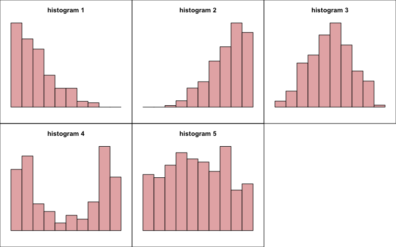

   - Which histogram is appropriate?
   - Which shape description is appropriate?

#### Solution

#### Question

2. A sample of size $n=200$ was taken from an unknown population. **Identify the correct histogram and describe the shape.** Note, the bucket size is 1.

   | 8.64 | 4.96 | 8.50 | 7.65 | 4.01 | 9.43 | 3.89 | 3.42 | 4.85 | 4.33 |
   | --- | --- | --- | --- | --- | --- | --- | --- | --- | --- |
   | 6.86 | 7.71 | 6.36 | 7.03 | 6.06 | 4.84 | 2.51 | 3.01 | 4.31 | 2.06 |
   | 2.92 | 6.98 | 8.28 | 5.59 | 3.88 | 3.89 | 5.71 | 5.28 | 2.47 | 1.95 |
   | 8.76 | 5.05 | 4.07 | 5.30 | 7.51 | 6.30 | 1.94 | 7.52 | 3.66 | 5.04 |
   | 3.32 | 4.83 | 4.17 | 5.12 | 6.39 | 5.59 | 3.21 | 5.68 | 7.29 | 5.01 |
   | 3.05 | 5.52 | 1.13 | 1.62 | 3.04 | 4.27 | 1.78 | 4.35 | 2.48 | 6.14 |
   | 6.96 | 1.45 | 5.12 | 6.21 | 5.87 | 2.31 | 4.38 | 3.63 | 6.68 | 4.54 |
   | 4.96 | 2.49 | 7.87 | 5.94 | 5.16 | 6.90 | 5.83 | 5.14 | 6.98 | 7.34 |
   | 5.64 | 3.73 | 1.45 | 1.65 | 4.31 | 6.02 | 6.41 | 3.35 | 3.77 | 2.99 |
   | 4.72 | 5.11 | 5.40 | 5.83 | 5.55 | 5.60 | 5.50 | 2.51 | 6.37 | 3.66 |
   | 8.53 | 3.94 | 4.97 | 3.43 | 2.83 | 5.54 | 3.86 | 6.34 | 3.89 | 3.54 |
   | 5.98 | 2.19 | 5.08 | 5.63 | 3.46 | 6.39 | 4.38 | 2.43 | 3.11 | 8.00 |
   | 7.37 | 3.48 | 2.48 | 7.15 | 6.29 | 5.19 | 4.10 | 7.18 | 5.59 | 5.99 |
   | 4.21 | 2.93 | 5.24 | 5.49 | 4.39 | 6.36 | 4.52 | 8.22 | 6.51 | 5.02 |
   | 2.18 | 3.28 | 6.14 | 4.74 | 6.51 | 5.53 | 2.73 | 5.93 | 6.22 | 3.85 |
   | 8.34 | 3.90 | 7.09 | 1.89 | 5.84 | 7.95 | 5.92 | 6.43 | 4.12 | 2.12 |
   | 5.84 | 6.04 | 6.64 | 6.65 | 2.38 | 6.49 | 4.39 | 5.54 | 5.82 | 3.44 |
   | 3.73 | 4.47 | 3.56 | 3.47 | 4.76 | 2.92 | 3.97 | 5.38 | 4.06 | 5.10 |
   | 3.66 | 7.77 | 1.43 | 6.68 | 3.52 | 3.75 | 5.08 | 5.71 | 5.57 | 3.51 |
   | 4.75 | 6.70 | 4.22 | 3.14 | 4.15 | 7.92 | 4.64 | 3.59 | 5.02 | 4.94 |

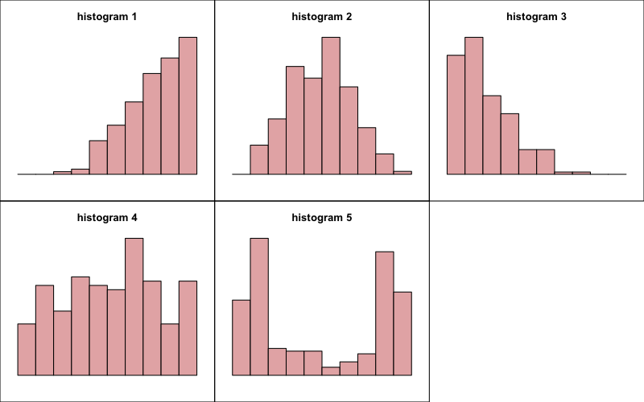

   - Which histogram is appropriate?
   - Which shape description is appropriate?

#### Solution

#### Question

3. A sample of size $n=200$ was taken from an unknown population. **Identify the correct histogram and describe the shape.** Note, the bucket size is 1.

   | 8.31 | 7.22 | 8.96 | 9.84 | 9.85 | 9.96 | 6.88 | 9.15 | 5.35 | 6.58 |
   | --- | --- | --- | --- | --- | --- | --- | --- | --- | --- |
   | 9.06 | 8.32 | 9.94 | 9.72 | 2.63 | 6.43 | 7.17 | 6.86 | 9.61 | 9.85 |
   | 6.55 | 9.93 | 5.76 | 5.27 | 9.76 | 7.86 | 7.02 | 9.42 | 9.63 | 5.75 |
   | 6.53 | 9.68 | 8.66 | 9.50 | 3.90 | 7.59 | 7.17 | 4.45 | 9.05 | 9.05 |
   | 9.19 | 9.15 | 6.34 | 7.91 | 7.13 | 9.46 | 6.54 | 8.96 | 8.89 | 7.59 |
   | 9.15 | 5.12 | 6.34 | 8.71 | 7.43 | 9.52 | 8.15 | 6.04 | 8.73 | 6.24 |
   | 6.28 | 8.78 | 7.98 | 8.95 | 6.21 | 7.78 | 7.29 | 8.60 | 5.71 | 3.87 |
   | 8.63 | 8.80 | 9.74 | 9.00 | 4.16 | 6.80 | 8.43 | 3.63 | 3.59 | 7.30 |
   | 9.83 | 7.86 | 9.12 | 7.26 | 7.98 | 8.68 | 9.68 | 6.16 | 8.15 | 7.67 |
   | 9.44 | 7.61 | 8.54 | 3.49 | 9.46 | 9.99 | 8.27 | 9.49 | 7.02 | 7.20 |
   | 5.31 | 4.33 | 7.27 | 8.39 | 7.95 | 7.72 | 7.86 | 9.52 | 9.40 | 9.47 |
   | 8.16 | 8.70 | 8.26 | 9.10 | 5.62 | 9.50 | 8.36 | 3.10 | 8.53 | 8.60 |
   | 9.18 | 7.05 | 5.14 | 8.60 | 6.81 | 4.49 | 9.74 | 9.15 | 6.29 | 7.51 |
   | 9.82 | 8.96 | 8.26 | 5.87 | 8.78 | 7.31 | 7.56 | 4.87 | 8.16 | 8.08 |
   | 9.27 | 9.68 | 8.68 | 9.05 | 8.73 | 5.49 | 8.87 | 6.22 | 7.38 | 6.80 |
   | 8.59 | 7.37 | 9.71 | 10.00 | 9.61 | 4.41 | 4.65 | 9.52 | 4.49 | 8.20 |
   | 8.44 | 3.93 | 5.81 | 4.76 | 6.34 | 7.32 | 9.81 | 3.17 | 5.96 | 9.31 |
   | 5.41 | 8.21 | 7.23 | 5.65 | 9.52 | 9.01 | 7.96 | 5.03 | 9.58 | 8.74 |
   | 7.32 | 6.68 | 6.42 | 5.39 | 9.53 | 9.17 | 9.16 | 8.35 | 5.68 | 7.90 |
   | 9.33 | 9.66 | 9.40 | 9.70 | 9.96 | 9.12 | 9.38 | 9.56 | 7.68 | 5.89 |

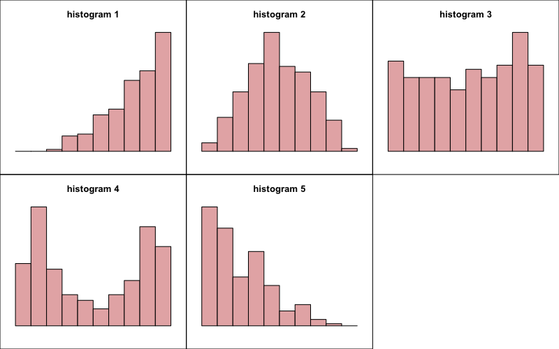

   - Which histogram is appropriate?
   - Which shape description is appropriate?

#### Solution

#### Question

4. A sample of size $n=200$ was taken from an unknown population. **Identify the correct histogram and describe the shape.** Note, the bucket size is 1.

   | 6.16 | 9.93 | 7.18 | 2.86 | 7.47 | 5.25 | 8.39 | 9.24 | 2.56 | 7.30 |
   | --- | --- | --- | --- | --- | --- | --- | --- | --- | --- |
   | 3.82 | 7.49 | 2.33 | 6.09 | 2.71 | 2.56 | 9.02 | 1.12 | 0.66 | 0.11 |
   | 8.06 | 4.04 | 4.63 | 2.88 | 5.68 | 8.92 | 6.41 | 6.03 | 0.35 | 0.73 |
   | 2.90 | 5.02 | 5.00 | 2.80 | 5.54 | 6.58 | 8.73 | 6.21 | 7.68 | 0.78 |
   | 8.86 | 0.38 | 6.11 | 7.87 | 2.01 | 0.25 | 2.73 | 0.46 | 0.58 | 8.88 |
   | 4.19 | 3.89 | 1.07 | 8.54 | 1.01 | 3.78 | 1.17 | 3.70 | 0.70 | 2.54 |
   | 5.23 | 3.17 | 5.81 | 4.26 | 3.17 | 6.11 | 0.93 | 7.58 | 3.39 | 4.66 |
   | 8.56 | 2.39 | 1.02 | 3.14 | 9.62 | 6.85 | 4.50 | 0.80 | 8.09 | 6.89 |
   | 1.43 | 0.13 | 3.31 | 3.12 | 7.60 | 4.98 | 1.98 | 7.02 | 8.17 | 9.44 |
   | 3.97 | 0.57 | 1.70 | 8.13 | 0.63 | 7.56 | 3.76 | 0.12 | 5.76 | 7.84 |
   | 5.95 | 7.53 | 0.32 | 8.90 | 5.50 | 5.12 | 0.26 | 6.49 | 0.60 | 4.35 |
   | 8.80 | 7.48 | 8.26 | 3.97 | 7.06 | 5.79 | 9.46 | 9.75 | 6.51 | 4.26 |
   | 3.13 | 2.32 | 5.25 | 5.96 | 8.25 | 7.27 | 5.91 | 8.23 | 4.34 | 7.73 |
   | 9.06 | 1.92 | 5.71 | 1.75 | 6.92 | 9.30 | 8.61 | 5.99 | 6.50 | 9.69 |
   | 9.83 | 5.04 | 2.05 | 0.51 | 1.91 | 1.20 | 2.74 | 3.90 | 8.74 | 0.84 |
   | 6.86 | 1.03 | 3.74 | 0.86 | 9.30 | 2.37 | 4.03 | 1.88 | 6.73 | 2.07 |
   | 2.71 | 0.02 | 4.39 | 9.64 | 9.38 | 2.12 | 9.40 | 2.74 | 4.57 | 7.39 |
   | 2.17 | 8.76 | 1.09 | 5.06 | 3.68 | 1.96 | 9.08 | 4.53 | 6.11 | 1.43 |
   | 3.36 | 9.09 | 7.20 | 8.24 | 6.28 | 8.60 | 8.52 | 5.55 | 2.88 | 5.37 |
   | 6.92 | 1.44 | 9.59 | 2.16 | 0.76 | 4.38 | 0.62 | 2.24 | 0.17 | 9.08 |

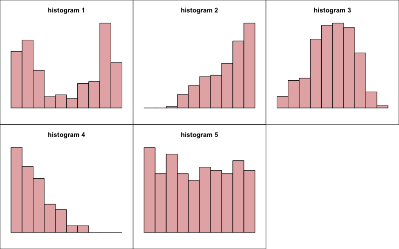

   - Which histogram is appropriate?
   - Which shape description is appropriate?

#### Solution

#### Question

5. A sample of size $n=200$ was taken from an unknown population. **Identify the correct histogram and describe the shape.** Note, the bucket size is 1.

   | 9.38 | 6.47 | 5.45 | 1.18 | 8.85 | 6.42 | 0.21 | 5.02 | 7.56 | 0.05 |
   | --- | --- | --- | --- | --- | --- | --- | --- | --- | --- |
   | 4.39 | 7.39 | 1.04 | 4.57 | 6.39 | 2.15 | 9.66 | 3.27 | 9.37 | 4.88 |
   | 4.39 | 4.54 | 1.22 | 2.78 | 5.93 | 4.07 | 6.64 | 3.52 | 9.07 | 0.83 |
   | 9.93 | 9.86 | 3.50 | 4.35 | 3.94 | 1.01 | 6.32 | 0.82 | 2.64 | 3.33 |
   | 0.63 | 0.22 | 3.43 | 4.26 | 9.50 | 3.94 | 0.93 | 0.45 | 5.39 | 2.02 |
   | 1.25 | 9.67 | 8.23 | 3.75 | 9.36 | 7.37 | 5.56 | 1.96 | 6.77 | 1.66 |
   | 9.21 | 7.28 | 5.76 | 7.60 | 0.30 | 0.36 | 0.48 | 0.17 | 3.85 | 9.59 |
   | 1.36 | 8.06 | 7.68 | 5.74 | 3.09 | 6.03 | 9.88 | 7.06 | 2.55 | 1.40 |
   | 4.94 | 0.59 | 3.73 | 6.56 | 2.23 | 3.34 | 2.87 | 7.63 | 0.33 | 5.26 |
   | 8.65 | 8.28 | 9.64 | 6.67 | 5.89 | 6.51 | 7.02 | 1.95 | 5.85 | 2.11 |
   | 5.47 | 5.54 | 3.58 | 4.77 | 4.23 | 5.81 | 0.10 | 1.46 | 8.89 | 0.27 |
   | 5.69 | 9.20 | 3.47 | 7.77 | 0.26 | 6.97 | 0.86 | 0.40 | 0.83 | 7.92 |
   | 4.54 | 0.35 | 4.55 | 0.69 | 0.34 | 2.12 | 5.65 | 7.79 | 2.74 | 6.66 |
   | 4.04 | 8.90 | 3.00 | 2.36 | 7.87 | 3.90 | 2.56 | 0.26 | 1.43 | 7.74 |
   | 9.38 | 9.86 | 8.25 | 1.21 | 8.76 | 0.20 | 2.36 | 7.71 | 2.10 | 1.05 |
   | 2.65 | 2.06 | 6.91 | 6.30 | 9.47 | 9.43 | 1.93 | 4.18 | 8.53 | 3.20 |
   | 1.78 | 0.65 | 5.07 | 6.31 | 5.24 | 1.02 | 3.20 | 5.61 | 7.41 | 1.43 |
   | 4.72 | 3.95 | 7.10 | 6.85 | 0.99 | 5.55 | 8.94 | 3.18 | 9.40 | 3.57 |
   | 0.77 | 5.76 | 1.88 | 4.36 | 3.52 | 2.00 | 9.86 | 5.61 | 8.32 | 9.21 |
   | 2.57 | 5.82 | 1.59 | 2.08 | 0.16 | 9.72 | 6.08 | 9.31 | 7.15 | 6.27 |

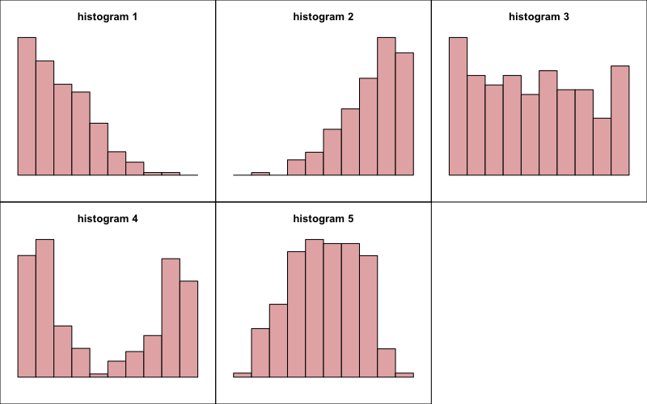

   - Which histogram is appropriate?
   - Which shape description is appropriate?

#### Solution

#### Question

6. A sample of size $n=200$ was taken from an unknown population. **Identify the correct histogram and describe the shape.** Note, the bucket size is 1.

   | 7.06 | 1.88 | 5.84 | 2.26 | 8.65 | 2.69 | 5.64 | 1.82 | 3.67 | 5.72 |
   | --- | --- | --- | --- | --- | --- | --- | --- | --- | --- |
   | 2.84 | 2.64 | 8.12 | 3.07 | 4.71 | 6.94 | 5.86 | 5.25 | 5.63 | 5.51 |
   | 4.88 | 3.22 | 1.50 | 6.16 | 6.46 | 2.18 | 3.27 | 1.71 | 8.07 | 4.56 |
   | 5.56 | 5.86 | 1.31 | 5.10 | 4.42 | 7.27 | 5.73 | 3.56 | 2.27 | 5.57 |
   | 9.42 | 6.71 | 4.49 | 4.39 | 1.54 | 5.43 | 4.11 | 3.85 | 6.48 | 4.12 |
   | 7.56 | 7.80 | 7.25 | 4.91 | 4.54 | 4.67 | 7.57 | 2.99 | 6.38 | 5.23 |
   | 3.01 | 4.66 | 7.16 | 2.27 | 7.82 | 5.16 | 3.82 | 4.55 | 2.87 | 3.76 |
   | 6.39 | 3.05 | 2.33 | 5.48 | 5.41 | 5.20 | 5.46 | 3.00 | 6.61 | 6.73 |
   | 6.14 | 6.61 | 4.74 | 6.38 | 3.50 | 4.48 | 5.08 | 4.06 | 2.66 | 6.09 |
   | 3.05 | 4.28 | 5.60 | 6.67 | 1.54 | 5.29 | 4.41 | 5.60 | 2.66 | 5.86 |
   | 8.37 | 6.98 | 4.47 | 2.64 | 6.25 | 5.48 | 6.08 | 6.59 | 5.87 | 5.83 |
   | 3.75 | 3.19 | 4.57 | 3.64 | 5.76 | 6.18 | 4.12 | 4.88 | 5.36 | 5.34 |
   | 6.82 | 4.43 | 6.97 | 5.60 | 6.66 | 7.59 | 5.80 | 6.71 | 5.21 | 5.05 |
   | 6.31 | 6.77 | 3.05 | 7.85 | 3.79 | 6.50 | 4.25 | 7.56 | 8.61 | 5.59 |
   | 7.03 | 1.85 | 5.86 | 3.45 | 2.86 | 8.17 | 6.10 | 2.65 | 5.59 | 0.83 |
   | 5.88 | 2.74 | 7.68 | 6.00 | 2.67 | 6.12 | 5.88 | 4.54 | 5.04 | 8.41 |
   | 5.01 | 5.81 | 3.29 | 3.13 | 6.99 | 5.82 | 5.46 | 7.49 | 6.14 | 7.81 |
   | 4.45 | 7.33 | 4.44 | 5.72 | 5.84 | 7.86 | 8.02 | 6.53 | 5.36 | 6.63 |
   | 3.56 | 5.44 | 5.00 | 7.92 | 5.37 | 5.56 | 4.10 | 6.69 | 5.43 | 7.48 |
   | 3.64 | 7.03 | 5.63 | 3.08 | 7.07 | 5.57 | 0.73 | 1.94 | 4.87 | 6.56 |

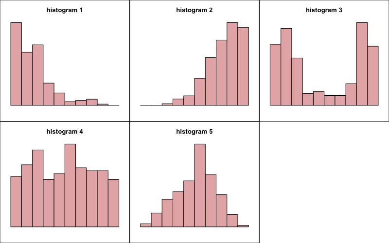

   - Which histogram is appropriate?
   - Which shape description is appropriate?

#### Solution

#### Question

7. A sample of size $n=200$ was taken from an unknown population. **Identify the correct histogram and describe the shape.** Note, the bucket size is 1.

   | 7.65 | 9.68 | 7.39 | 4.27 | 7.19 | 8.27 | 5.17 | 4.91 | 5.67 | 9.10 |
   | --- | --- | --- | --- | --- | --- | --- | --- | --- | --- |
   | 9.79 | 7.90 | 9.82 | 8.13 | 6.37 | 8.42 | 5.50 | 9.68 | 6.82 | 9.34 |
   | 8.90 | 9.91 | 6.27 | 7.47 | 9.76 | 9.68 | 6.53 | 9.17 | 7.15 | 9.82 |
   | 7.77 | 9.63 | 9.76 | 4.77 | 8.30 | 8.11 | 9.90 | 8.61 | 6.91 | 3.83 |
   | 8.49 | 8.72 | 7.20 | 7.35 | 8.40 | 4.40 | 8.48 | 4.63 | 4.40 | 9.08 |
   | 6.86 | 7.06 | 6.59 | 3.94 | 7.98 | 7.34 | 4.55 | 7.91 | 8.03 | 5.04 |
   | 9.25 | 8.37 | 9.10 | 8.17 | 9.21 | 6.76 | 9.27 | 9.42 | 3.88 | 6.51 |
   | 8.19 | 8.91 | 6.54 | 8.03 | 9.44 | 2.47 | 8.97 | 7.70 | 8.99 | 5.95 |
   | 9.31 | 9.71 | 8.94 | 5.99 | 4.08 | 6.51 | 6.80 | 8.42 | 7.87 | 7.53 |
   | 9.41 | 9.88 | 8.41 | 3.36 | 9.61 | 7.10 | 5.81 | 8.88 | 9.09 | 8.67 |
   | 6.66 | 8.86 | 9.70 | 9.91 | 8.21 | 8.56 | 5.29 | 4.34 | 9.56 | 8.52 |
   | 7.52 | 5.23 | 9.73 | 8.31 | 7.46 | 6.45 | 8.07 | 6.92 | 8.97 | 6.66 |
   | 5.77 | 7.73 | 4.13 | 9.07 | 8.81 | 9.17 | 9.81 | 9.68 | 8.94 | 9.54 |
   | 6.19 | 7.55 | 8.68 | 9.84 | 3.51 | 7.80 | 7.22 | 9.21 | 8.28 | 7.79 |
   | 9.18 | 7.24 | 7.09 | 8.71 | 9.73 | 7.24 | 9.10 | 9.08 | 9.86 | 7.59 |
   | 7.65 | 9.29 | 9.39 | 9.11 | 6.44 | 8.93 | 9.44 | 9.23 | 4.84 | 7.36 |
   | 9.82 | 7.26 | 9.28 | 3.27 | 8.26 | 7.40 | 9.46 | 7.04 | 6.38 | 6.96 |
   | 6.74 | 5.44 | 6.93 | 9.04 | 8.02 | 8.52 | 9.80 | 7.85 | 7.13 | 2.95 |
   | 6.31 | 7.26 | 7.03 | 8.91 | 8.62 | 9.11 | 5.33 | 5.66 | 8.13 | 5.89 |
   | 5.75 | 9.28 | 7.79 | 7.98 | 8.39 | 9.48 | 7.33 | 9.18 | 7.70 | 4.07 |

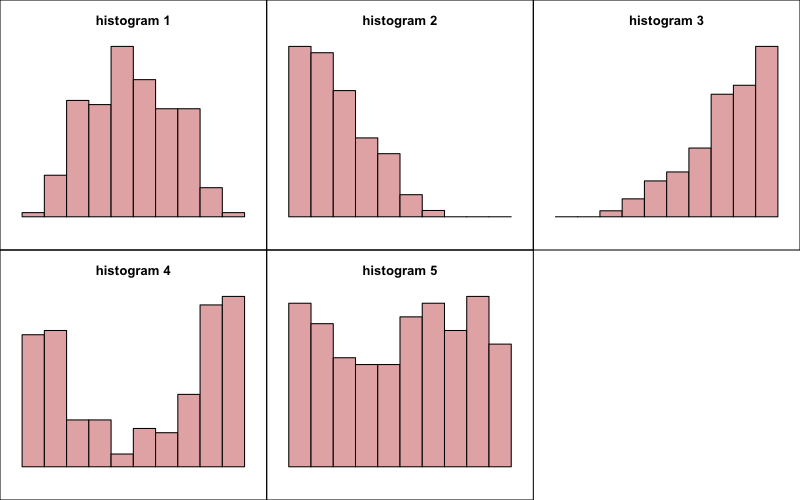

   - Which histogram is appropriate?
   - Which shape description is appropriate?

#### Solution

#### Question

8. A sample of size $n=200$ was taken from an unknown population. **Identify the correct histogram and describe the shape.** Note, the bucket size is 1.

   | 6.91 | 8.68 | 2.31 | 8.92 | 8.96 | 8.22 | 6.50 | 9.77 | 8.54 | 9.93 |
   | --- | --- | --- | --- | --- | --- | --- | --- | --- | --- |
   | 9.24 | 5.27 | 7.10 | 7.12 | 8.27 | 7.62 | 9.61 | 6.00 | 9.11 | 9.27 |
   | 8.83 | 9.42 | 9.73 | 4.64 | 6.86 | 8.40 | 9.09 | 8.79 | 6.45 | 5.53 |
   | 7.37 | 7.92 | 5.94 | 9.15 | 9.37 | 5.81 | 9.68 | 7.36 | 6.95 | 9.69 |
   | 7.20 | 8.05 | 4.87 | 9.23 | 8.04 | 8.20 | 7.30 | 4.75 | 3.61 | 5.46 |
   | 6.72 | 7.45 | 9.00 | 9.87 | 8.98 | 3.45 | 9.71 | 8.33 | 8.57 | 9.32 |
   | 7.19 | 7.13 | 9.47 | 8.93 | 7.46 | 8.65 | 9.28 | 7.71 | 8.14 | 8.80 |
   | 9.83 | 9.31 | 4.60 | 7.33 | 8.22 | 9.19 | 9.07 | 7.01 | 9.16 | 8.77 |
   | 5.54 | 8.38 | 7.47 | 8.00 | 8.21 | 6.63 | 5.80 | 9.10 | 7.04 | 7.32 |
   | 9.16 | 8.69 | 8.40 | 6.39 | 9.04 | 6.10 | 9.69 | 8.09 | 5.93 | 7.11 |
   | 5.89 | 9.48 | 9.41 | 9.84 | 9.60 | 9.17 | 8.90 | 7.05 | 6.59 | 9.14 |
   | 7.22 | 7.93 | 8.18 | 7.28 | 6.49 | 9.63 | 8.27 | 8.39 | 8.35 | 7.35 |
   | 8.29 | 5.99 | 9.01 | 6.91 | 7.26 | 7.30 | 7.87 | 8.47 | 8.34 | 6.18 |
   | 7.15 | 3.08 | 8.45 | 9.84 | 5.23 | 6.25 | 8.19 | 8.22 | 7.31 | 9.76 |
   | 8.86 | 8.86 | 7.74 | 2.90 | 9.39 | 7.83 | 4.95 | 9.30 | 9.50 | 8.37 |
   | 6.95 | 6.24 | 6.73 | 9.25 | 8.55 | 6.50 | 8.52 | 9.67 | 3.78 | 7.24 |
   | 8.50 | 9.82 | 9.01 | 9.21 | 5.36 | 6.29 | 9.16 | 8.23 | 7.05 | 9.56 |
   | 9.34 | 7.80 | 8.02 | 5.69 | 6.89 | 6.77 | 8.92 | 8.79 | 7.54 | 7.09 |
   | 9.68 | 5.64 | 6.92 | 8.64 | 9.75 | 8.63 | 5.81 | 9.17 | 9.94 | 8.44 |
   | 6.82 | 9.06 | 9.68 | 8.98 | 6.11 | 8.63 | 9.11 | 8.06 | 2.19 | 9.85 |

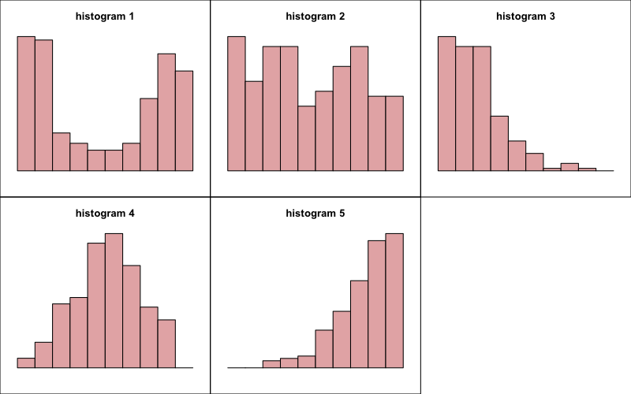

   - Which histogram is appropriate?
   - Which shape description is appropriate?

#### Solution

#### Question

9. A sample of size $n=200$ was taken from an unknown population. **Identify the correct histogram and describe the shape.** Note, the bucket size is 1.

   | 0.44 | 2.06 | 1.02 | 1.99 | 0.45 | 1.36 | 0.13 | 2.06 | 2.87 | 2.28 |
   | --- | --- | --- | --- | --- | --- | --- | --- | --- | --- |
   | 0.97 | 1.54 | 0.27 | 5.37 | 1.17 | 0.79 | 3.76 | 3.39 | 3.18 | 0.15 |
   | 3.64 | 2.40 | 1.72 | 0.88 | 2.82 | 1.14 | 2.57 | 0.79 | 1.75 | 0.27 |
   | 2.84 | 1.10 | 4.01 | 2.42 | 3.64 | 0.27 | 4.13 | 3.16 | 0.75 | 3.46 |
   | 2.02 | 2.02 | 2.02 | 0.31 | 6.45 | 5.80 | 2.61 | 4.85 | 3.13 | 4.79 |
   | 0.06 | 3.78 | 0.21 | 0.31 | 0.17 | 2.92 | 1.66 | 2.75 | 2.19 | 0.99 |
   | 0.07 | 0.69 | 1.90 | 4.75 | 3.22 | 1.02 | 1.49 | 3.36 | 2.01 | 0.55 |
   | 1.56 | 1.38 | 2.44 | 1.07 | 6.19 | 0.73 | 4.53 | 1.67 | 0.93 | 3.16 |
   | 0.42 | 3.26 | 3.14 | 1.69 | 2.37 | 2.33 | 6.23 | 2.16 | 0.42 | 1.91 |
   | 1.29 | 3.82 | 1.25 | 6.56 | 5.54 | 1.94 | 0.62 | 1.16 | 0.58 | 2.39 |
   | 3.94 | 1.89 | 0.50 | 0.15 | 1.45 | 0.90 | 1.79 | 1.82 | 2.12 | 0.93 |
   | 1.07 | 0.96 | 0.25 | 1.95 | 0.35 | 0.16 | 4.03 | 3.86 | 3.35 | 6.34 |
   | 0.14 | 0.69 | 3.58 | 1.00 | 1.21 | 0.32 | 5.60 | 0.53 | 4.26 | 6.36 |
   | 1.71 | 0.45 | 5.44 | 2.30 | 1.53 | 3.75 | 0.82 | 1.97 | 1.07 | 1.89 |
   | 2.72 | 4.41 | 8.40 | 1.57 | 3.13 | 0.37 | 1.51 | 2.34 | 0.66 | 1.83 |
   | 5.45 | 0.22 | 2.10 | 2.72 | 1.91 | 4.23 | 4.11 | 0.33 | 2.95 | 1.08 |
   | 4.48 | 0.99 | 1.16 | 0.20 | 0.05 | 1.32 | 0.24 | 3.21 | 2.05 | 1.60 |
   | 0.34 | 4.77 | 2.87 | 6.34 | 0.30 | 3.91 | 5.03 | 1.57 | 1.63 | 0.52 |
   | 0.52 | 1.17 | 0.51 | 0.61 | 3.00 | 3.85 | 1.36 | 0.50 | 6.00 | 0.92 |
   | 0.37 | 0.07 | 1.95 | 1.48 | 0.45 | 3.33 | 1.54 | 1.05 | 1.99 | 0.49 |

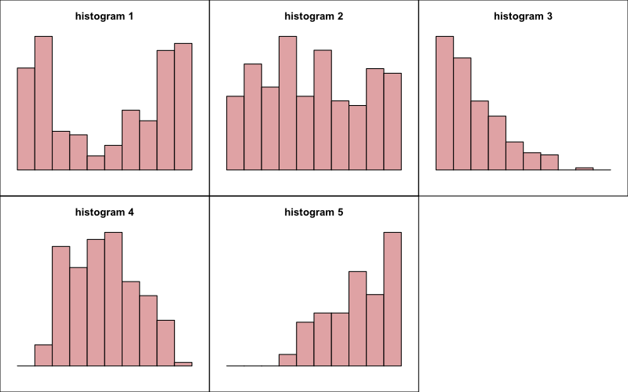

   - Which histogram is appropriate?
   - Which shape description is appropriate?

#### Solution

#### Question

10. A sample of size $n=200$ was taken from an unknown population. **Identify the correct histogram and describe the shape.** Note, the bucket size is 1.

    | 9.53 | 8.07 | 9.94 | 7.09 | 8.65 | 5.32 | 4.28 | 9.25 | 8.57 | 8.29 |
    | --- | --- | --- | --- | --- | --- | --- | --- | --- | --- |
    | 7.84 | 4.97 | 9.39 | 8.22 | 7.22 | 6.60 | 8.79 | 6.33 | 4.75 | 7.14 |
    | 8.64 | 9.17 | 6.37 | 9.34 | 7.70 | 5.41 | 5.02 | 8.32 | 9.33 | 8.61 |
    | 7.98 | 9.55 | 8.58 | 6.01 | 8.96 | 7.48 | 7.99 | 9.38 | 9.68 | 6.53 |
    | 7.45 | 9.75 | 6.39 | 9.56 | 7.09 | 9.07 | 5.30 | 5.76 | 9.59 | 6.96 |
    | 6.51 | 6.37 | 7.68 | 6.50 | 8.15 | 8.31 | 8.74 | 8.63 | 9.65 | 8.14 |
    | 9.51 | 8.14 | 7.71 | 7.30 | 8.17 | 9.10 | 7.59 | 2.87 | 8.08 | 7.91 |
    | 8.97 | 8.45 | 4.06 | 7.97 | 8.66 | 8.19 | 8.98 | 2.84 | 9.74 | 8.58 |
    | 6.12 | 3.25 | 9.75 | 9.90 | 8.39 | 9.81 | 9.81 | 4.97 | 9.13 | 6.11 |
    | 9.13 | 8.47 | 4.89 | 9.01 | 2.72 | 9.78 | 9.90 | 7.38 | 7.78 | 4.23 |
    | 8.03 | 8.67 | 6.64 | 8.90 | 3.83 | 8.23 | 7.60 | 9.17 | 9.66 | 9.39 |
    | 9.42 | 9.12 | 7.94 | 9.90 | 8.88 | 6.22 | 8.77 | 9.69 | 3.90 | 5.69 |
    | 6.94 | 9.23 | 7.26 | 8.00 | 8.19 | 9.10 | 8.81 | 8.72 | 7.11 | 9.65 |
    | 5.65 | 4.63 | 6.51 | 8.60 | 9.17 | 9.36 | 8.92 | 8.31 | 9.97 | 9.34 |
    | 7.50 | 8.78 | 7.79 | 2.37 | 3.91 | 9.07 | 5.31 | 5.38 | 5.26 | 6.42 |
    | 7.57 | 8.86 | 6.04 | 8.90 | 9.02 | 7.61 | 9.43 | 9.90 | 9.81 | 6.22 |
    | 7.82 | 8.89 | 7.41 | 7.47 | 9.30 | 8.09 | 9.73 | 6.75 | 9.69 | 4.84 |
    | 8.99 | 5.81 | 6.18 | 9.21 | 8.60 | 6.59 | 9.21 | 9.24 | 4.51 | 8.18 |
    | 8.69 | 9.63 | 8.91 | 9.80 | 9.57 | 6.67 | 7.09 | 8.94 | 6.13 | 9.59 |
    | 7.20 | 4.82 | 9.65 | 8.09 | 2.83 | 8.43 | 7.41 | 9.87 | 6.32 | 8.94 |

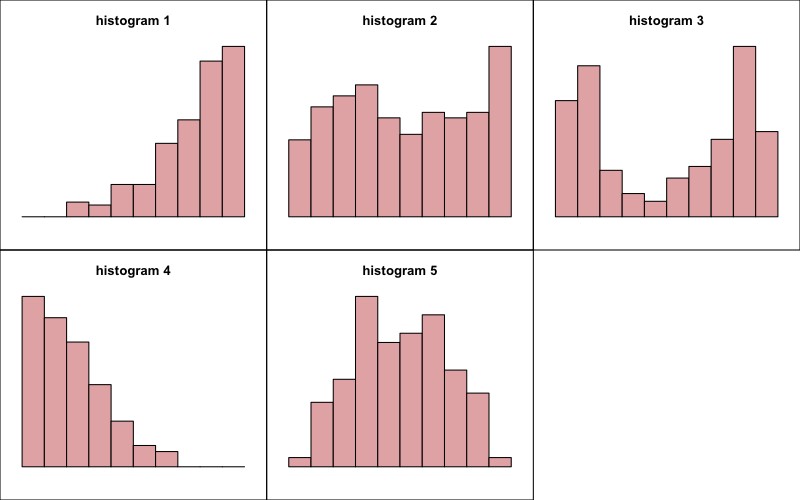

    - Which histogram is appropriate?
    - Which shape description is appropriate?

#### Solution

#### Question

11. A scientist has weighed 217 specimens of a newly discovered organism. Those weights have a [*sample mean*](https://en.wikipedia.org/wiki/Sample_mean_and_covariance#Definition_of_the_sample_mean) equaling $\bar{x} =27.4$ grams and a [sample standard deviation](https://en.wikipedia.org/wiki/Unbiased_estimation_of_standard_deviation#Motivation) equaling $s=5.7$ grams. The scientist hopes to construct a 95% [**confidence interval**](https://en.wikipedia.org/wiki/Confidence_interval) of the organism’s [*population mean*](https://en.wikipedia.org/wiki/Statistical_population#Mean) ($\mu$).

    The scientist will later consult a statistician for a more precise method, but for now she will use a quick method to estimate the 95% confidence interval:
    $$\text{CI boundaries} = \bar{x}\pm \frac{2s}{\sqrt{n}}$$

    The lower boundary is .

    The upper boundary is .

#### Solution

#### Question

12. A scientist has weighed 260 specimens of a newly discovered organism. Those weights have a [*sample mean*](https://en.wikipedia.org/wiki/Sample_mean_and_covariance#Definition_of_the_sample_mean) equaling $\bar{x} =90.4$ grams and a [sample standard deviation](https://en.wikipedia.org/wiki/Unbiased_estimation_of_standard_deviation#Motivation) equaling $s=21.3$ grams. The scientist hopes to construct a 95% [**confidence interval**](https://en.wikipedia.org/wiki/Confidence_interval) of the organism’s [*population mean*](https://en.wikipedia.org/wiki/Statistical_population#Mean) ($\mu$).

    The scientist will later consult a statistician for a more precise method, but for now she will use a quick method to estimate the 95% confidence interval:
    $$\text{CI boundaries} = \bar{x}\pm \frac{2s}{\sqrt{n}}$$

    The lower boundary is .

    The upper boundary is .

#### Solution

#### Question

13. A scientist has weighed 81 specimens of a newly discovered organism. Those weights have a [*sample mean*](https://en.wikipedia.org/wiki/Sample_mean_and_covariance#Definition_of_the_sample_mean) equaling $\bar{x} =25.5$ grams and a [sample standard deviation](https://en.wikipedia.org/wiki/Unbiased_estimation_of_standard_deviation#Motivation) equaling $s=6$ grams. The scientist hopes to construct a 95% [**confidence interval**](https://en.wikipedia.org/wiki/Confidence_interval) of the organism’s [*population mean*](https://en.wikipedia.org/wiki/Statistical_population#Mean) ($\mu$).

    The scientist will later consult a statistician for a more precise method, but for now she will use a quick method to estimate the 95% confidence interval:
    $$\text{CI boundaries} = \bar{x}\pm \frac{2s}{\sqrt{n}}$$

    The lower boundary is .

    The upper boundary is .

#### Solution

#### Question

14. A scientist has weighed 249 specimens of a newly discovered organism. Those weights have a [*sample mean*](https://en.wikipedia.org/wiki/Sample_mean_and_covariance#Definition_of_the_sample_mean) equaling $\bar{x} =28$ grams and a [sample standard deviation](https://en.wikipedia.org/wiki/Unbiased_estimation_of_standard_deviation#Motivation) equaling $s=8.8$ grams. The scientist hopes to construct a 95% [**confidence interval**](https://en.wikipedia.org/wiki/Confidence_interval) of the organism’s [*population mean*](https://en.wikipedia.org/wiki/Statistical_population#Mean) ($\mu$).

    The scientist will later consult a statistician for a more precise method, but for now she will use a quick method to estimate the 95% confidence interval:
    $$\text{CI boundaries} = \bar{x}\pm \frac{2s}{\sqrt{n}}$$

    The lower boundary is .

    The upper boundary is .

#### Solution

#### Question

15. A scientist has weighed 222 specimens of a newly discovered organism. Those weights have a [*sample mean*](https://en.wikipedia.org/wiki/Sample_mean_and_covariance#Definition_of_the_sample_mean) equaling $\bar{x} =52.3$ grams and a [sample standard deviation](https://en.wikipedia.org/wiki/Unbiased_estimation_of_standard_deviation#Motivation) equaling $s=15.6$ grams. The scientist hopes to construct a 95% [**confidence interval**](https://en.wikipedia.org/wiki/Confidence_interval) of the organism’s [*population mean*](https://en.wikipedia.org/wiki/Statistical_population#Mean) ($\mu$).

    The scientist will later consult a statistician for a more precise method, but for now she will use a quick method to estimate the 95% confidence interval:
    $$\text{CI boundaries} = \bar{x}\pm \frac{2s}{\sqrt{n}}$$

    The lower boundary is .

    The upper boundary is .

#### Solution

#### Question

16. A scientist has weighed 226 specimens of a newly discovered organism. Those weights have a [*sample mean*](https://en.wikipedia.org/wiki/Sample_mean_and_covariance#Definition_of_the_sample_mean) equaling $\bar{x} =89.3$ grams and a [sample standard deviation](https://en.wikipedia.org/wiki/Unbiased_estimation_of_standard_deviation#Motivation) equaling $s=22.9$ grams. The scientist hopes to construct a 95% [**confidence interval**](https://en.wikipedia.org/wiki/Confidence_interval) of the organism’s [*population mean*](https://en.wikipedia.org/wiki/Statistical_population#Mean) ($\mu$).

    The scientist will later consult a statistician for a more precise method, but for now she will use a quick method to estimate the 95% confidence interval:
    $$\text{CI boundaries} = \bar{x}\pm \frac{2s}{\sqrt{n}}$$

    The lower boundary is .

    The upper boundary is .

#### Solution

#### Question

17. A scientist has weighed 83 specimens of a newly discovered organism. Those weights have a [*sample mean*](https://en.wikipedia.org/wiki/Sample_mean_and_covariance#Definition_of_the_sample_mean) equaling $\bar{x} =33.1$ grams and a [sample standard deviation](https://en.wikipedia.org/wiki/Unbiased_estimation_of_standard_deviation#Motivation) equaling $s=8.6$ grams. The scientist hopes to construct a 95% [**confidence interval**](https://en.wikipedia.org/wiki/Confidence_interval) of the organism’s [*population mean*](https://en.wikipedia.org/wiki/Statistical_population#Mean) ($\mu$).

    The scientist will later consult a statistician for a more precise method, but for now she will use a quick method to estimate the 95% confidence interval:
    $$\text{CI boundaries} = \bar{x}\pm \frac{2s}{\sqrt{n}}$$

    The lower boundary is .

    The upper boundary is .

#### Solution

#### Question

18. A scientist has weighed 256 specimens of a newly discovered organism. Those weights have a [*sample mean*](https://en.wikipedia.org/wiki/Sample_mean_and_covariance#Definition_of_the_sample_mean) equaling $\bar{x} =77.7$ grams and a [sample standard deviation](https://en.wikipedia.org/wiki/Unbiased_estimation_of_standard_deviation#Motivation) equaling $s=15.9$ grams. The scientist hopes to construct a 95% [**confidence interval**](https://en.wikipedia.org/wiki/Confidence_interval) of the organism’s [*population mean*](https://en.wikipedia.org/wiki/Statistical_population#Mean) ($\mu$).

    The scientist will later consult a statistician for a more precise method, but for now she will use a quick method to estimate the 95% confidence interval:
    $$\text{CI boundaries} = \bar{x}\pm \frac{2s}{\sqrt{n}}$$

    The lower boundary is .

    The upper boundary is .

#### Solution

#### Question

19. A scientist has weighed 202 specimens of a newly discovered organism. Those weights have a [*sample mean*](https://en.wikipedia.org/wiki/Sample_mean_and_covariance#Definition_of_the_sample_mean) equaling $\bar{x} =73.5$ grams and a [sample standard deviation](https://en.wikipedia.org/wiki/Unbiased_estimation_of_standard_deviation#Motivation) equaling $s=18.3$ grams. The scientist hopes to construct a 95% [**confidence interval**](https://en.wikipedia.org/wiki/Confidence_interval) of the organism’s [*population mean*](https://en.wikipedia.org/wiki/Statistical_population#Mean) ($\mu$).

    The scientist will later consult a statistician for a more precise method, but for now she will use a quick method to estimate the 95% confidence interval:
    $$\text{CI boundaries} = \bar{x}\pm \frac{2s}{\sqrt{n}}$$

    The lower boundary is .

    The upper boundary is .

#### Solution

#### Question

20. A scientist has weighed 135 specimens of a newly discovered organism. Those weights have a [*sample mean*](https://en.wikipedia.org/wiki/Sample_mean_and_covariance#Definition_of_the_sample_mean) equaling $\bar{x} =87.6$ grams and a [sample standard deviation](https://en.wikipedia.org/wiki/Unbiased_estimation_of_standard_deviation#Motivation) equaling $s=16.4$ grams. The scientist hopes to construct a 95% [**confidence interval**](https://en.wikipedia.org/wiki/Confidence_interval) of the organism’s [*population mean*](https://en.wikipedia.org/wiki/Statistical_population#Mean) ($\mu$).

    The scientist will later consult a statistician for a more precise method, but for now she will use a quick method to estimate the 95% confidence interval:
    $$\text{CI boundaries} = \bar{x}\pm \frac{2s}{\sqrt{n}}$$

    The lower boundary is .

    The upper boundary is .

#### Solution

#### Question

21. A scientist measured weights of a [simple-random sample](https://en.wikipedia.org/wiki/Simple_random_sample) of a newly discovered organism. Those weights are given below (in grams):

    | x |
    | --- |
    | 56.8 |
    | 42.6 |
    | 55.7 |
    | 46.9 |
    | 43.2 |
    | 44.2 |
    | 42.6 |
    | 41.6 |
    | 49.5 |
    | 41.5 |
    | 54.3 |
    | 49.4 |
    | 55.1 |
    | 55.6 |
    | 43.3 |
    | 47.9 |
    | 43.8 |
    | 55.9 |
    | 43.0 |
    | 40.8 |
    | 58.4 |
    | 52.1 |
    | 54.0 |
    | 42.9 |
    | 47.8 |
    | 57.0 |
    | 50.0 |
    | 55.5 |
    | 46.8 |
    | 41.4 |
    | 55.1 |
    | 40.6 |
    | 42.2 |
    | 44.0 |
    | 41.7 |
    | 40.9 |

    The scientist hopes to construct a 95% [**confidence interval**](https://en.wikipedia.org/wiki/Confidence_interval) of the organism’s [*population mean*](https://en.wikipedia.org/wiki/Statistical_population#Mean) weight ($\mu$).

    The scientist will later consult a statistician for a more precise method, but for now they will use a quick method to estimate the 95% confidence interval:
    $$\text{CI boundaries} = \bar{x}\pm \frac{2s}{\sqrt{n}}$$

    In interval notation, the confidence interval is [, ].

#### Solution

#### Question

22. A scientist measured weights of a [simple-random sample](https://en.wikipedia.org/wiki/Simple_random_sample) of a newly discovered organism. Those weights are given below (in grams):

    | x |
    | --- |
    | 41.9 |
    | 41.6 |
    | 43.0 |
    | 42.6 |
    | 47.5 |
    | 42.7 |
    | 47.2 |
    | 42.7 |
    | 46.8 |
    | 44.6 |
    | 44.3 |
    | 46.5 |
    | 41.3 |
    | 45.9 |
    | 45.7 |
    | 42.9 |
    | 43.3 |
    | 45.2 |
    | 47.2 |
    | 43.2 |
    | 46.8 |
    | 44.5 |
    | 47.0 |
    | 40.0 |
    | 38.9 |
    | 40.2 |
    | 47.4 |
    | 41.2 |
    | 47.1 |
    | 47.5 |
    | 45.8 |
    | 45.8 |
    | 43.6 |
    | 41.5 |
    | 44.6 |
    | 43.3 |
    | 45.5 |
    | 38.7 |
    | 47.1 |
    | 46.9 |
    | 43.7 |
    | 44.2 |
    | 40.1 |
    | 47.1 |
    | 40.8 |
    | 45.9 |
    | 45.6 |
    | 47.3 |
    | 47.8 |

    The scientist hopes to construct a 95% [**confidence interval**](https://en.wikipedia.org/wiki/Confidence_interval) of the organism’s [*population mean*](https://en.wikipedia.org/wiki/Statistical_population#Mean) weight ($\mu$).

    The scientist will later consult a statistician for a more precise method, but for now they will use a quick method to estimate the 95% confidence interval:
    $$\text{CI boundaries} = \bar{x}\pm \frac{2s}{\sqrt{n}}$$

    In interval notation, the confidence interval is [, ].

#### Solution

#### Question

23. A scientist measured weights of a [simple-random sample](https://en.wikipedia.org/wiki/Simple_random_sample) of a newly discovered organism. Those weights are given below (in grams):

    | x |
    | --- |
    | 43.1 |
    | 52.1 |
    | 47.2 |
    | 41.9 |
    | 42.4 |
    | 49.4 |
    | 45.9 |
    | 45.3 |
    | 49.9 |
    | 42.9 |
    | 42.8 |
    | 47.4 |
    | 41.7 |
    | 47.3 |
    | 45.7 |
    | 46.4 |
    | 43.7 |
    | 44.4 |
    | 42.3 |
    | 44.8 |
    | 49.7 |
    | 46.4 |
    | 44.2 |
    | 44.3 |
    | 43.2 |
    | 45.7 |
    | 46.3 |
    | 47.2 |
    | 43.4 |
    | 51.3 |
    | 47.6 |
    | 47.0 |
    | 46.7 |
    | 44.5 |
    | 42.5 |
    | 45.1 |
    | 44.8 |
    | 45.6 |
    | 42.6 |
    | 48.1 |
    | 45.3 |
    | 45.0 |
    | 47.1 |
    | 47.6 |
    | 46.3 |
    | 48.4 |
    | 46.9 |
    | 46.9 |

    The scientist hopes to construct a 95% [**confidence interval**](https://en.wikipedia.org/wiki/Confidence_interval) of the organism’s [*population mean*](https://en.wikipedia.org/wiki/Statistical_population#Mean) weight ($\mu$).

    The scientist will later consult a statistician for a more precise method, but for now they will use a quick method to estimate the 95% confidence interval:
    $$\text{CI boundaries} = \bar{x}\pm \frac{2s}{\sqrt{n}}$$

    In interval notation, the confidence interval is [, ].

#### Solution

#### Question

24. A scientist measured weights of a [simple-random sample](https://en.wikipedia.org/wiki/Simple_random_sample) of a newly discovered organism. Those weights are given below (in grams):

    | x |
    | --- |
    | 82.2 |
    | 81.2 |
    | 93.2 |
    | 92.1 |
    | 89.4 |
    | 92.8 |
    | 80.9 |
    | 84.2 |
    | 87.0 |
    | 81.3 |
    | 93.3 |
    | 84.7 |
    | 92.0 |
    | 91.6 |
    | 92.9 |
    | 90.9 |
    | 92.6 |
    | 93.2 |
    | 88.7 |
    | 84.2 |
    | 84.0 |
    | 93.3 |
    | 85.4 |
    | 92.6 |
    | 90.6 |
    | 90.3 |
    | 85.3 |
    | 88.9 |

    The scientist hopes to construct a 95% [**confidence interval**](https://en.wikipedia.org/wiki/Confidence_interval) of the organism’s [*population mean*](https://en.wikipedia.org/wiki/Statistical_population#Mean) weight ($\mu$).

    The scientist will later consult a statistician for a more precise method, but for now they will use a quick method to estimate the 95% confidence interval:
    $$\text{CI boundaries} = \bar{x}\pm \frac{2s}{\sqrt{n}}$$

    In interval notation, the confidence interval is [, ].

#### Solution

#### Question

25. A scientist measured weights of a [simple-random sample](https://en.wikipedia.org/wiki/Simple_random_sample) of a newly discovered organism. Those weights are given below (in grams):

    | x |
    | --- |
    | 80.8 |
    | 72.8 |
    | 88.5 |
    | 74.5 |
    | 82.9 |
    | 79.8 |
    | 79.6 |
    | 80.2 |
    | 77.9 |
    | 75.0 |
    | 73.7 |
    | 85.8 |
    | 83.1 |
    | 82.4 |
    | 86.5 |
    | 73.2 |
    | 81.0 |
    | 80.2 |
    | 75.8 |
    | 82.1 |
    | 84.4 |
    | 80.7 |
    | 80.4 |
    | 81.2 |
    | 74.8 |

    The scientist hopes to construct a 95% [**confidence interval**](https://en.wikipedia.org/wiki/Confidence_interval) of the organism’s [*population mean*](https://en.wikipedia.org/wiki/Statistical_population#Mean) weight ($\mu$).

    The scientist will later consult a statistician for a more precise method, but for now they will use a quick method to estimate the 95% confidence interval:
    $$\text{CI boundaries} = \bar{x}\pm \frac{2s}{\sqrt{n}}$$

    In interval notation, the confidence interval is [, ].

#### Solution

#### Question

26. A scientist measured weights of a [simple-random sample](https://en.wikipedia.org/wiki/Simple_random_sample) of a newly discovered organism. Those weights are given below (in grams):

    | x |
    | --- |
    | 16.7 |
    | 15.2 |
    | 12.6 |
    | 12.3 |
    | 12.4 |
    | 12.4 |
    | 13.8 |
    | 14.3 |
    | 12.4 |
    | 16.3 |
    | 15.3 |
    | 15.3 |
    | 12.2 |
    | 16.0 |
    | 12.5 |
    | 12.2 |
    | 11.5 |
    | 14.2 |
    | 14.4 |
    | 13.9 |
    | 14.8 |
    | 11.6 |
    | 12.7 |
    | 16.1 |
    | 16.5 |
    | 14.3 |

    The scientist hopes to construct a 95% [**confidence interval**](https://en.wikipedia.org/wiki/Confidence_interval) of the organism’s [*population mean*](https://en.wikipedia.org/wiki/Statistical_population#Mean) weight ($\mu$).

    The scientist will later consult a statistician for a more precise method, but for now they will use a quick method to estimate the 95% confidence interval:
    $$\text{CI boundaries} = \bar{x}\pm \frac{2s}{\sqrt{n}}$$

    In interval notation, the confidence interval is [, ].

#### Solution

#### Question

27. A scientist measured weights of a [simple-random sample](https://en.wikipedia.org/wiki/Simple_random_sample) of a newly discovered organism. Those weights are given below (in grams):

    | x |
    | --- |
    | 27.3 |
    | 28.3 |
    | 31.3 |
    | 29.2 |
    | 28.1 |
    | 27.0 |
    | 29.0 |
    | 35.3 |
    | 29.2 |
    | 30.8 |
    | 30.7 |
    | 27.0 |
    | 31.3 |
    | 27.3 |
    | 28.4 |
    | 29.2 |
    | 26.9 |
    | 33.0 |
    | 29.4 |
    | 33.2 |
    | 31.8 |
    | 34.3 |
    | 33.9 |
    | 28.1 |
    | 29.6 |
    | 29.3 |
    | 28.0 |
    | 27.4 |
    | 27.1 |
    | 29.5 |
    | 33.4 |

    The scientist hopes to construct a 95% [**confidence interval**](https://en.wikipedia.org/wiki/Confidence_interval) of the organism’s [*population mean*](https://en.wikipedia.org/wiki/Statistical_population#Mean) weight ($\mu$).

    The scientist will later consult a statistician for a more precise method, but for now they will use a quick method to estimate the 95% confidence interval:
    $$\text{CI boundaries} = \bar{x}\pm \frac{2s}{\sqrt{n}}$$

    In interval notation, the confidence interval is [, ].

#### Solution

#### Question

28. A scientist measured weights of a [simple-random sample](https://en.wikipedia.org/wiki/Simple_random_sample) of a newly discovered organism. Those weights are given below (in grams):

    | x |
    | --- |
    | 22.0 |
    | 17.6 |
    | 19.8 |
    | 21.1 |
    | 18.8 |
    | 18.9 |
    | 18.3 |
    | 17.8 |
    | 17.6 |
    | 18.0 |
    | 21.4 |
    | 17.7 |
    | 19.6 |
    | 21.0 |
    | 17.7 |
    | 23.0 |
    | 18.8 |
    | 18.2 |
    | 17.9 |
    | 20.5 |
    | 22.7 |
    | 17.6 |
    | 21.1 |
    | 19.0 |
    | 24.7 |
    | 17.6 |
    | 17.9 |
    | 17.8 |
    | 20.5 |
    | 17.6 |
    | 21.3 |
    | 19.6 |
    | 19.3 |
    | 18.4 |
    | 18.9 |
    | 18.1 |
    | 19.1 |
    | 20.9 |
    | 25.0 |
    | 19.6 |
    | 17.8 |
    | 19.2 |
    | 21.0 |
    | 17.6 |
    | 17.7 |
    | 18.0 |
    | 18.8 |
    | 18.6 |

    The scientist hopes to construct a 95% [**confidence interval**](https://en.wikipedia.org/wiki/Confidence_interval) of the organism’s [*population mean*](https://en.wikipedia.org/wiki/Statistical_population#Mean) weight ($\mu$).

    The scientist will later consult a statistician for a more precise method, but for now they will use a quick method to estimate the 95% confidence interval:
    $$\text{CI boundaries} = \bar{x}\pm \frac{2s}{\sqrt{n}}$$

    In interval notation, the confidence interval is [, ].

#### Solution

#### Question

29. A scientist measured weights of a [simple-random sample](https://en.wikipedia.org/wiki/Simple_random_sample) of a newly discovered organism. Those weights are given below (in grams):

    | x |
    | --- |
    | 68.2 |
    | 65.8 |
    | 65.9 |
    | 58.9 |
    | 64.2 |
    | 65.0 |
    | 66.7 |
    | 70.1 |
    | 63.5 |
    | 57.4 |
    | 58.1 |
    | 63.7 |
    | 63.0 |
    | 64.5 |
    | 66.4 |
    | 63.7 |
    | 59.1 |
    | 64.8 |
    | 65.7 |
    | 66.9 |
    | 59.8 |
    | 59.9 |
    | 68.9 |
    | 67.7 |
    | 63.4 |
    | 70.7 |
    | 61.0 |
    | 65.7 |
    | 63.8 |
    | 68.7 |
    | 67.3 |
    | 60.0 |

    The scientist hopes to construct a 95% [**confidence interval**](https://en.wikipedia.org/wiki/Confidence_interval) of the organism’s [*population mean*](https://en.wikipedia.org/wiki/Statistical_population#Mean) weight ($\mu$).

    The scientist will later consult a statistician for a more precise method, but for now they will use a quick method to estimate the 95% confidence interval:
    $$\text{CI boundaries} = \bar{x}\pm \frac{2s}{\sqrt{n}}$$

    In interval notation, the confidence interval is [, ].

#### Solution

#### Question

30. A scientist measured weights of a [simple-random sample](https://en.wikipedia.org/wiki/Simple_random_sample) of a newly discovered organism. Those weights are given below (in grams):

    | x |
    | --- |
    | 40.6 |
    | 40.1 |
    | 39.9 |
    | 42.0 |
    | 43.4 |
    | 43.3 |
    | 40.5 |
    | 35.8 |
    | 39.6 |
    | 37.0 |
    | 43.7 |
    | 39.6 |
    | 43.4 |
    | 37.1 |
    | 41.5 |
    | 32.5 |
    | 43.4 |
    | 43.6 |
    | 38.3 |
    | 40.6 |
    | 36.5 |
    | 44.7 |
    | 40.5 |
    | 38.3 |
    | 33.1 |
    | 41.5 |
    | 42.5 |
    | 40.5 |
    | 39.1 |
    | 43.6 |
    | 41.3 |
    | 39.2 |
    | 41.4 |
    | 40.6 |
    | 40.8 |
    | 41.8 |
    | 41.1 |
    | 36.0 |
    | 38.7 |
    | 39.3 |
    | 38.0 |

    The scientist hopes to construct a 95% [**confidence interval**](https://en.wikipedia.org/wiki/Confidence_interval) of the organism’s [*population mean*](https://en.wikipedia.org/wiki/Statistical_population#Mean) weight ($\mu$).

    The scientist will later consult a statistician for a more precise method, but for now they will use a quick method to estimate the 95% confidence interval:
    $$\text{CI boundaries} = \bar{x}\pm \frac{2s}{\sqrt{n}}$$

    In interval notation, the confidence interval is [, ].

#### Solution

#### Question

31. A pollster is trying to determine the proportion of likely voters who are still undecided (*note: in Statistics, the definition of “proportion” is distinct from other definitions; it refers to a quotient of counts, part over whole, giving a number between 0 and 1*.) They randomly select 161 likely voters, and in that sample 55.3% are still undecided. The pollster wishes to calculate the boundaries of a [confidence interval of the proportion](https://en.wikipedia.org/wiki/Population_proportion#Estimation).

    Proportions are a special case: an average of 0s (not undecided) and 1s (undecided). In this special case, the single parameter (sample proportion $\hat{p}=0.553$) determines the sample mean $\bar{x}$ and the sample standard deviation $s$.

    $$\bar{x} = \hat{p}$$

    $$s = \sqrt{\hat{p}(1-\hat{p})}$$

    The approximate formula to calculate the boundaries of a confidence interval remains the same, except [Bessel’s correction](https://en.wikipedia.org/wiki/Bessel%27s_correction) is not used to calculate $s$ (due to a complicated argument involving degrees of freedom and because both $\bar{x}$ and $s$ are determined from ${\hat{p}}$).
    $$\text{CI boundaries} = \bar{x} \pm \frac{2s}{\sqrt{n}}$$

    This formula can also be rewritten in terms of $\hat{p}$.
    $$\text{CI boundaries (proportion)} = \hat{p} \pm 2 \sqrt{\frac{\hat{p}(1-\hat{p})}{n}}$$
    **Calculate the confidence-interval boundaries**.

    The confidence interval is [, ].

#### Solution

#### Question

32. A pollster is trying to determine the proportion of likely voters who are still undecided (*note: in Statistics, the definition of “proportion” is distinct from other definitions; it refers to a quotient of counts, part over whole, giving a number between 0 and 1*.) They randomly select 225 likely voters, and in that sample 56.4% are still undecided. The pollster wishes to calculate the boundaries of a [confidence interval of the proportion](https://en.wikipedia.org/wiki/Population_proportion#Estimation).

    Proportions are a special case: an average of 0s (not undecided) and 1s (undecided). In this special case, the single parameter (sample proportion $\hat{p}=0.564$) determines the sample mean $\bar{x}$ and the sample standard deviation $s$.

    $$\bar{x} = \hat{p}$$

    $$s = \sqrt{\hat{p}(1-\hat{p})}$$

    The approximate formula to calculate the boundaries of a confidence interval remains the same, except [Bessel’s correction](https://en.wikipedia.org/wiki/Bessel%27s_correction) is not used to calculate $s$ (due to a complicated argument involving degrees of freedom and because both $\bar{x}$ and $s$ are determined from ${\hat{p}}$).
    $$\text{CI boundaries} = \bar{x} \pm \frac{2s}{\sqrt{n}}$$

    This formula can also be rewritten in terms of $\hat{p}$.
    $$\text{CI boundaries (proportion)} = \hat{p} \pm 2 \sqrt{\frac{\hat{p}(1-\hat{p})}{n}}$$
    **Calculate the confidence-interval boundaries**.

    The confidence interval is [, ].

#### Solution

#### Question

33. A pollster is trying to determine the proportion of likely voters who are still undecided (*note: in Statistics, the definition of “proportion” is distinct from other definitions; it refers to a quotient of counts, part over whole, giving a number between 0 and 1*.) They randomly select 84 likely voters, and in that sample 45.2% are still undecided. The pollster wishes to calculate the boundaries of a [confidence interval of the proportion](https://en.wikipedia.org/wiki/Population_proportion#Estimation).

    Proportions are a special case: an average of 0s (not undecided) and 1s (undecided). In this special case, the single parameter (sample proportion $\hat{p}=0.452$) determines the sample mean $\bar{x}$ and the sample standard deviation $s$.

    $$\bar{x} = \hat{p}$$

    $$s = \sqrt{\hat{p}(1-\hat{p})}$$

    The approximate formula to calculate the boundaries of a confidence interval remains the same, except [Bessel’s correction](https://en.wikipedia.org/wiki/Bessel%27s_correction) is not used to calculate $s$ (due to a complicated argument involving degrees of freedom and because both $\bar{x}$ and $s$ are determined from ${\hat{p}}$).
    $$\text{CI boundaries} = \bar{x} \pm \frac{2s}{\sqrt{n}}$$

    This formula can also be rewritten in terms of $\hat{p}$.
    $$\text{CI boundaries (proportion)} = \hat{p} \pm 2 \sqrt{\frac{\hat{p}(1-\hat{p})}{n}}$$
    **Calculate the confidence-interval boundaries**.

    The confidence interval is [, ].

#### Solution

#### Question

34. A pollster is trying to determine the proportion of likely voters who are still undecided (*note: in Statistics, the definition of “proportion” is distinct from other definitions; it refers to a quotient of counts, part over whole, giving a number between 0 and 1*.) They randomly select 297 likely voters, and in that sample 21.9% are still undecided. The pollster wishes to calculate the boundaries of a [confidence interval of the proportion](https://en.wikipedia.org/wiki/Population_proportion#Estimation).

    Proportions are a special case: an average of 0s (not undecided) and 1s (undecided). In this special case, the single parameter (sample proportion $\hat{p}=0.219$) determines the sample mean $\bar{x}$ and the sample standard deviation $s$.

    $$\bar{x} = \hat{p}$$

    $$s = \sqrt{\hat{p}(1-\hat{p})}$$

    The approximate formula to calculate the boundaries of a confidence interval remains the same, except [Bessel’s correction](https://en.wikipedia.org/wiki/Bessel%27s_correction) is not used to calculate $s$ (due to a complicated argument involving degrees of freedom and because both $\bar{x}$ and $s$ are determined from ${\hat{p}}$).
    $$\text{CI boundaries} = \bar{x} \pm \frac{2s}{\sqrt{n}}$$

    This formula can also be rewritten in terms of $\hat{p}$.
    $$\text{CI boundaries (proportion)} = \hat{p} \pm 2 \sqrt{\frac{\hat{p}(1-\hat{p})}{n}}$$
    **Calculate the confidence-interval boundaries**.

    The confidence interval is [, ].

#### Solution

#### Question

35. A pollster is trying to determine the proportion of likely voters who are still undecided (*note: in Statistics, the definition of “proportion” is distinct from other definitions; it refers to a quotient of counts, part over whole, giving a number between 0 and 1*.) They randomly select 140 likely voters, and in that sample 30.7% are still undecided. The pollster wishes to calculate the boundaries of a [confidence interval of the proportion](https://en.wikipedia.org/wiki/Population_proportion#Estimation).

    Proportions are a special case: an average of 0s (not undecided) and 1s (undecided). In this special case, the single parameter (sample proportion $\hat{p}=0.307$) determines the sample mean $\bar{x}$ and the sample standard deviation $s$.

    $$\bar{x} = \hat{p}$$

    $$s = \sqrt{\hat{p}(1-\hat{p})}$$

    The approximate formula to calculate the boundaries of a confidence interval remains the same, except [Bessel’s correction](https://en.wikipedia.org/wiki/Bessel%27s_correction) is not used to calculate $s$ (due to a complicated argument involving degrees of freedom and because both $\bar{x}$ and $s$ are determined from ${\hat{p}}$).
    $$\text{CI boundaries} = \bar{x} \pm \frac{2s}{\sqrt{n}}$$

    This formula can also be rewritten in terms of $\hat{p}$.
    $$\text{CI boundaries (proportion)} = \hat{p} \pm 2 \sqrt{\frac{\hat{p}(1-\hat{p})}{n}}$$
    **Calculate the confidence-interval boundaries**.

    The confidence interval is [, ].

#### Solution

#### Question

36. A pollster is trying to determine the proportion of likely voters who are still undecided (*note: in Statistics, the definition of “proportion” is distinct from other definitions; it refers to a quotient of counts, part over whole, giving a number between 0 and 1*.) They randomly select 59 likely voters, and in that sample 15.3% are still undecided. The pollster wishes to calculate the boundaries of a [confidence interval of the proportion](https://en.wikipedia.org/wiki/Population_proportion#Estimation).

    Proportions are a special case: an average of 0s (not undecided) and 1s (undecided). In this special case, the single parameter (sample proportion $\hat{p}=0.153$) determines the sample mean $\bar{x}$ and the sample standard deviation $s$.

    $$\bar{x} = \hat{p}$$

    $$s = \sqrt{\hat{p}(1-\hat{p})}$$

    The approximate formula to calculate the boundaries of a confidence interval remains the same, except [Bessel’s correction](https://en.wikipedia.org/wiki/Bessel%27s_correction) is not used to calculate $s$ (due to a complicated argument involving degrees of freedom and because both $\bar{x}$ and $s$ are determined from ${\hat{p}}$).
    $$\text{CI boundaries} = \bar{x} \pm \frac{2s}{\sqrt{n}}$$

    This formula can also be rewritten in terms of $\hat{p}$.
    $$\text{CI boundaries (proportion)} = \hat{p} \pm 2 \sqrt{\frac{\hat{p}(1-\hat{p})}{n}}$$
    **Calculate the confidence-interval boundaries**.

    The confidence interval is [, ].

#### Solution

#### Question

37. A pollster is trying to determine the proportion of likely voters who are still undecided (*note: in Statistics, the definition of “proportion” is distinct from other definitions; it refers to a quotient of counts, part over whole, giving a number between 0 and 1*.) They randomly select 101 likely voters, and in that sample 49.5% are still undecided. The pollster wishes to calculate the boundaries of a [confidence interval of the proportion](https://en.wikipedia.org/wiki/Population_proportion#Estimation).

    Proportions are a special case: an average of 0s (not undecided) and 1s (undecided). In this special case, the single parameter (sample proportion $\hat{p}=0.495$) determines the sample mean $\bar{x}$ and the sample standard deviation $s$.

    $$\bar{x} = \hat{p}$$

    $$s = \sqrt{\hat{p}(1-\hat{p})}$$

    The approximate formula to calculate the boundaries of a confidence interval remains the same, except [Bessel’s correction](https://en.wikipedia.org/wiki/Bessel%27s_correction) is not used to calculate $s$ (due to a complicated argument involving degrees of freedom and because both $\bar{x}$ and $s$ are determined from ${\hat{p}}$).
    $$\text{CI boundaries} = \bar{x} \pm \frac{2s}{\sqrt{n}}$$

    This formula can also be rewritten in terms of $\hat{p}$.
    $$\text{CI boundaries (proportion)} = \hat{p} \pm 2 \sqrt{\frac{\hat{p}(1-\hat{p})}{n}}$$
    **Calculate the confidence-interval boundaries**.

    The confidence interval is [, ].

#### Solution

#### Question

38. A pollster is trying to determine the proportion of likely voters who are still undecided (*note: in Statistics, the definition of “proportion” is distinct from other definitions; it refers to a quotient of counts, part over whole, giving a number between 0 and 1*.) They randomly select 153 likely voters, and in that sample 34% are still undecided. The pollster wishes to calculate the boundaries of a [confidence interval of the proportion](https://en.wikipedia.org/wiki/Population_proportion#Estimation).

    Proportions are a special case: an average of 0s (not undecided) and 1s (undecided). In this special case, the single parameter (sample proportion $\hat{p}=0.34$) determines the sample mean $\bar{x}$ and the sample standard deviation $s$.

    $$\bar{x} = \hat{p}$$

    $$s = \sqrt{\hat{p}(1-\hat{p})}$$

    The approximate formula to calculate the boundaries of a confidence interval remains the same, except [Bessel’s correction](https://en.wikipedia.org/wiki/Bessel%27s_correction) is not used to calculate $s$ (due to a complicated argument involving degrees of freedom and because both $\bar{x}$ and $s$ are determined from ${\hat{p}}$).
    $$\text{CI boundaries} = \bar{x} \pm \frac{2s}{\sqrt{n}}$$

    This formula can also be rewritten in terms of $\hat{p}$.
    $$\text{CI boundaries (proportion)} = \hat{p} \pm 2 \sqrt{\frac{\hat{p}(1-\hat{p})}{n}}$$
    **Calculate the confidence-interval boundaries**.

    The confidence interval is [, ].

#### Solution

#### Question

39. A pollster is trying to determine the proportion of likely voters who are still undecided (*note: in Statistics, the definition of “proportion” is distinct from other definitions; it refers to a quotient of counts, part over whole, giving a number between 0 and 1*.) They randomly select 214 likely voters, and in that sample 65.4% are still undecided. The pollster wishes to calculate the boundaries of a [confidence interval of the proportion](https://en.wikipedia.org/wiki/Population_proportion#Estimation).

    Proportions are a special case: an average of 0s (not undecided) and 1s (undecided). In this special case, the single parameter (sample proportion $\hat{p}=0.654$) determines the sample mean $\bar{x}$ and the sample standard deviation $s$.

    $$\bar{x} = \hat{p}$$

    $$s = \sqrt{\hat{p}(1-\hat{p})}$$

    The approximate formula to calculate the boundaries of a confidence interval remains the same, except [Bessel’s correction](https://en.wikipedia.org/wiki/Bessel%27s_correction) is not used to calculate $s$ (due to a complicated argument involving degrees of freedom and because both $\bar{x}$ and $s$ are determined from ${\hat{p}}$).
    $$\text{CI boundaries} = \bar{x} \pm \frac{2s}{\sqrt{n}}$$

    This formula can also be rewritten in terms of $\hat{p}$.
    $$\text{CI boundaries (proportion)} = \hat{p} \pm 2 \sqrt{\frac{\hat{p}(1-\hat{p})}{n}}$$
    **Calculate the confidence-interval boundaries**.

    The confidence interval is [, ].

#### Solution

#### Question

40. A pollster is trying to determine the proportion of likely voters who are still undecided (*note: in Statistics, the definition of “proportion” is distinct from other definitions; it refers to a quotient of counts, part over whole, giving a number between 0 and 1*.) They randomly select 44 likely voters, and in that sample 38.6% are still undecided. The pollster wishes to calculate the boundaries of a [confidence interval of the proportion](https://en.wikipedia.org/wiki/Population_proportion#Estimation).

    Proportions are a special case: an average of 0s (not undecided) and 1s (undecided). In this special case, the single parameter (sample proportion $\hat{p}=0.386$) determines the sample mean $\bar{x}$ and the sample standard deviation $s$.

    $$\bar{x} = \hat{p}$$

    $$s = \sqrt{\hat{p}(1-\hat{p})}$$

    The approximate formula to calculate the boundaries of a confidence interval remains the same, except [Bessel’s correction](https://en.wikipedia.org/wiki/Bessel%27s_correction) is not used to calculate $s$ (due to a complicated argument involving degrees of freedom and because both $\bar{x}$ and $s$ are determined from ${\hat{p}}$).
    $$\text{CI boundaries} = \bar{x} \pm \frac{2s}{\sqrt{n}}$$

    This formula can also be rewritten in terms of $\hat{p}$.
    $$\text{CI boundaries (proportion)} = \hat{p} \pm 2 \sqrt{\frac{\hat{p}(1-\hat{p})}{n}}$$
    **Calculate the confidence-interval boundaries**.

    The confidence interval is [, ].

#### Solution

#### Question

41. In an upcoming election, there are only two candidates: Candidate A and Candidate B. Each of the millions of people who will vote is easy to contact, has a preferred candidate, will honestly tell a pollster their preferred candidate, and won’t change their opinion before the election.

    (Imagine an overly simple election run-up.)

    A pollster asks a simple-random sample of voters if they will vote for Candidate A. The answers are coded as a 1 if they say “yes” and 0 if they say “no”. The results are shown below.

    | 1 | 0 | 0 | 1 | 1 | 1 | 1 | 0 | 0 | 1 |
    | --- | --- | --- | --- | --- | --- | --- | --- | --- | --- |
    | 1 | 0 | 0 | 1 | 0 | 1 | 1 | 1 | 0 | 1 |
    | 0 | 0 | 0 | 1 | 1 | 1 | 1 | 1 | 0 | 0 |
    | 0 | 1 | 1 | 1 | 1 | 1 | 1 | 0 | 1 | 1 |
    | 0 | 0 | 0 | 0 | 0 | 0 | 0 | 0 | 1 | 0 |
    | 0 | 1 | 0 | 1 | 1 | 1 | 0 | 0 | 1 | 1 |
    | 1 | 0 | 1 | 1 | 1 | 1 | 1 | 0 | 0 | 1 |
    | 0 | 1 | 1 | 0 | 1 | 1 | 1 | 0 | 0 | 1 |
    | 0 | 1 | 0 | 1 | 0 | 0 | 0 | 1 | 1 | 1 |
    | 1 | 0 | 0 | 1 | 1 | 1 | 1 | 0 | 1 | 0 |
    | 0 | 1 | 1 | 0 | 0 | 0 | 1 | 1 | 0 | 0 |

    The approximate formula to calculate the boundaries of a confidence interval of a mean is still appropriate for this proportion, as long as you do **NOT** use Bessel’s correction when calculating $s$.
    $$\text{CI boundaries} = \bar{x} \pm \frac{2s}{\sqrt{n}}$$

    This formula can also be rewritten in terms of $\hat{p}$, since $\bar{x}=\hat{p}$ and $s=\sqrt{\hat{p}(1-\hat{p})}$.
    $$\text{CI boundaries (proportion)} = \hat{p} \pm 2 \sqrt{\frac{\hat{p}(1-\hat{p})}{n}}$$

    **Calculate the confidence-interval boundaries**.

    The confidence interval is [, ].

    What conclusion will the pollster infer?

#### Solution

#### Question

42. In an upcoming election, there are only two candidates: Candidate A and Candidate B. Each of the millions of people who will vote is easy to contact, has a preferred candidate, will honestly tell a pollster their preferred candidate, and won’t change their opinion before the election.

    (Imagine an overly simple election run-up.)

    A pollster asks a simple-random sample of voters if they will vote for Candidate A. The answers are coded as a 1 if they say “yes” and 0 if they say “no”. The results are shown below.

    | 0 | 0 | 1 | 0 | 0 | 0 | 0 | 1 | 0 | 0 | 1 |
    | --- | --- | --- | --- | --- | --- | --- | --- | --- | --- | --- |
    | 0 | 0 | 1 | 0 | 0 | 1 | 0 | 1 | 0 | 1 | 0 |
    | 1 | 0 | 0 | 0 | 1 | 1 | 0 | 1 | 1 | 0 | 1 |
    | 0 | 0 | 0 | 1 | 0 | 0 | 1 | 1 | 0 | 1 | 0 |
    | 0 | 1 | 1 | 0 | 1 | 0 | 1 | 0 | 1 | 1 | 0 |
    | 1 | 0 | 1 | 1 | 0 | 1 | 1 | 1 | 1 | 0 | 0 |
    | 0 | 0 | 0 | 0 | 0 | 0 | 0 | 1 | 1 | 0 | 0 |
    | 0 | 0 | 1 | 1 | 1 | 0 | 0 | 0 | 1 | 1 | 1 |
    | 1 | 0 | 1 | 0 | 1 | 1 | 0 | 0 | 0 | 1 | 1 |
    | 0 | 1 | 0 | 0 | 1 | 1 | 0 | 0 | 1 | 1 | 0 |
    | 0 | 0 | 0 | 0 | 0 | 1 | 1 | 1 | 0 | 1 | 0 |
    | 0 | 0 | 1 | 1 | 1 | 0 | 1 | 0 | 0 | 0 | 1 |

    The approximate formula to calculate the boundaries of a confidence interval of a mean is still appropriate for this proportion, as long as you do **NOT** use Bessel’s correction when calculating $s$.
    $$\text{CI boundaries} = \bar{x} \pm \frac{2s}{\sqrt{n}}$$

    This formula can also be rewritten in terms of $\hat{p}$, since $\bar{x}=\hat{p}$ and $s=\sqrt{\hat{p}(1-\hat{p})}$.
    $$\text{CI boundaries (proportion)} = \hat{p} \pm 2 \sqrt{\frac{\hat{p}(1-\hat{p})}{n}}$$

    **Calculate the confidence-interval boundaries**.

    The confidence interval is [, ].

    What conclusion will the pollster infer?

#### Solution

#### Question

43. In an upcoming election, there are only two candidates: Candidate A and Candidate B. Each of the millions of people who will vote is easy to contact, has a preferred candidate, will honestly tell a pollster their preferred candidate, and won’t change their opinion before the election.

    (Imagine an overly simple election run-up.)

    A pollster asks a simple-random sample of voters if they will vote for Candidate A. The answers are coded as a 1 if they say “yes” and 0 if they say “no”. The results are shown below.

    | 1 | 0 | 1 | 1 | 1 |
    | --- | --- | --- | --- | --- |
    | 1 | 1 | 1 | 1 | 0 |
    | 1 | 1 | 0 | 0 | 1 |
    | 0 | 0 | 0 | 1 | 0 |
    | 0 | 0 | 0 | 0 | 0 |
    | 0 | 1 | 0 | 1 | 0 |
    | 0 | 0 | 0 | 1 | 0 |

    The approximate formula to calculate the boundaries of a confidence interval of a mean is still appropriate for this proportion, as long as you do **NOT** use Bessel’s correction when calculating $s$.
    $$\text{CI boundaries} = \bar{x} \pm \frac{2s}{\sqrt{n}}$$

    This formula can also be rewritten in terms of $\hat{p}$, since $\bar{x}=\hat{p}$ and $s=\sqrt{\hat{p}(1-\hat{p})}$.
    $$\text{CI boundaries (proportion)} = \hat{p} \pm 2 \sqrt{\frac{\hat{p}(1-\hat{p})}{n}}$$

    **Calculate the confidence-interval boundaries**.

    The confidence interval is [, ].

    What conclusion will the pollster infer?

#### Solution

#### Question

44. In an upcoming election, there are only two candidates: Candidate A and Candidate B. Each of the millions of people who will vote is easy to contact, has a preferred candidate, will honestly tell a pollster their preferred candidate, and won’t change their opinion before the election.

    (Imagine an overly simple election run-up.)

    A pollster asks a simple-random sample of voters if they will vote for Candidate A. The answers are coded as a 1 if they say “yes” and 0 if they say “no”. The results are shown below.

    | 0 | 0 | 0 | 0 | 1 | 0 |
    | --- | --- | --- | --- | --- | --- |
    | 1 | 1 | 1 | 0 | 0 | 0 |
    | 0 | 1 | 0 | 0 | 0 | 1 |
    | 0 | 0 | 1 | 0 | 1 | 1 |
    | 0 | 1 | 0 | 1 | 0 | 1 |
    | 0 | 0 | 1 | 1 | 0 | 1 |
    | 1 | 1 | 0 | 1 | 1 | 0 |
    | 1 | 1 | 0 | 1 | 1 | 0 |
    | 0 | 1 | 1 | 0 | 1 | 0 |
    | 1 | 0 | 1 | 0 | 0 | 1 |
    | 1 | 1 | 0 | 1 | 0 | 1 |

    The approximate formula to calculate the boundaries of a confidence interval of a mean is still appropriate for this proportion, as long as you do **NOT** use Bessel’s correction when calculating $s$.
    $$\text{CI boundaries} = \bar{x} \pm \frac{2s}{\sqrt{n}}$$

    This formula can also be rewritten in terms of $\hat{p}$, since $\bar{x}=\hat{p}$ and $s=\sqrt{\hat{p}(1-\hat{p})}$.
    $$\text{CI boundaries (proportion)} = \hat{p} \pm 2 \sqrt{\frac{\hat{p}(1-\hat{p})}{n}}$$

    **Calculate the confidence-interval boundaries**.

    The confidence interval is [, ].

    What conclusion will the pollster infer?

#### Solution

#### Question

45. In an upcoming election, there are only two candidates: Candidate A and Candidate B. Each of the millions of people who will vote is easy to contact, has a preferred candidate, will honestly tell a pollster their preferred candidate, and won’t change their opinion before the election.

    (Imagine an overly simple election run-up.)

    A pollster asks a simple-random sample of voters if they will vote for Candidate A. The answers are coded as a 1 if they say “yes” and 0 if they say “no”. The results are shown below.

    | 0 | 0 | 1 | 0 | 0 | 0 | 0 | 0 |
    | --- | --- | --- | --- | --- | --- | --- | --- |
    | 0 | 1 | 1 | 0 | 0 | 0 | 0 | 1 |
    | 0 | 1 | 0 | 0 | 0 | 1 | 1 | 1 |
    | 1 | 1 | 1 | 0 | 0 | 0 | 1 | 1 |
    | 0 | 0 | 0 | 1 | 0 | 0 | 0 | 0 |
    | 0 | 1 | 1 | 0 | 0 | 0 | 0 | 0 |
    | 0 | 0 | 1 | 0 | 0 | 1 | 1 | 1 |
    | 1 | 0 | 0 | 0 | 0 | 1 | 0 | 0 |
    | 0 | 0 | 0 | 0 | 0 | 0 | 0 | 0 |
    | 1 | 1 | 0 | 0 | 1 | 0 | 1 | 0 |

    The approximate formula to calculate the boundaries of a confidence interval of a mean is still appropriate for this proportion, as long as you do **NOT** use Bessel’s correction when calculating $s$.
    $$\text{CI boundaries} = \bar{x} \pm \frac{2s}{\sqrt{n}}$$

    This formula can also be rewritten in terms of $\hat{p}$, since $\bar{x}=\hat{p}$ and $s=\sqrt{\hat{p}(1-\hat{p})}$.
    $$\text{CI boundaries (proportion)} = \hat{p} \pm 2 \sqrt{\frac{\hat{p}(1-\hat{p})}{n}}$$

    **Calculate the confidence-interval boundaries**.

    The confidence interval is [, ].

    What conclusion will the pollster infer?

#### Solution

#### Question

46. In an upcoming election, there are only two candidates: Candidate A and Candidate B. Each of the millions of people who will vote is easy to contact, has a preferred candidate, will honestly tell a pollster their preferred candidate, and won’t change their opinion before the election.

    (Imagine an overly simple election run-up.)

    A pollster asks a simple-random sample of voters if they will vote for Candidate A. The answers are coded as a 1 if they say “yes” and 0 if they say “no”. The results are shown below.

    | 0 | 0 | 0 | 0 | 0 | 1 | 1 |
    | --- | --- | --- | --- | --- | --- | --- |
    | 1 | 0 | 0 | 0 | 0 | 1 | 0 |
    | 1 | 1 | 1 | 0 | 0 | 1 | 1 |
    | 0 | 1 | 0 | 1 | 0 | 1 | 0 |
    | 1 | 0 | 0 | 0 | 1 | 0 | 0 |
    | 0 | 0 | 0 | 0 | 0 | 0 | 0 |
    | 1 | 1 | 1 | 1 | 0 | 0 | 0 |
    | 1 | 0 | 0 | 1 | 1 | 1 | 0 |

    The approximate formula to calculate the boundaries of a confidence interval of a mean is still appropriate for this proportion, as long as you do **NOT** use Bessel’s correction when calculating $s$.
    $$\text{CI boundaries} = \bar{x} \pm \frac{2s}{\sqrt{n}}$$

    This formula can also be rewritten in terms of $\hat{p}$, since $\bar{x}=\hat{p}$ and $s=\sqrt{\hat{p}(1-\hat{p})}$.
    $$\text{CI boundaries (proportion)} = \hat{p} \pm 2 \sqrt{\frac{\hat{p}(1-\hat{p})}{n}}$$

    **Calculate the confidence-interval boundaries**.

    The confidence interval is [, ].

    What conclusion will the pollster infer?

#### Solution

#### Question

47. In an upcoming election, there are only two candidates: Candidate A and Candidate B. Each of the millions of people who will vote is easy to contact, has a preferred candidate, will honestly tell a pollster their preferred candidate, and won’t change their opinion before the election.

    (Imagine an overly simple election run-up.)

    A pollster asks a simple-random sample of voters if they will vote for Candidate A. The answers are coded as a 1 if they say “yes” and 0 if they say “no”. The results are shown below.

    | 1 | 0 | 0 | 0 | 1 |
    | --- | --- | --- | --- | --- |
    | 1 | 1 | 1 | 1 | 1 |
    | 1 | 1 | 1 | 1 | 1 |
    | 1 | 1 | 1 | 1 | 1 |
    | 1 | 0 | 1 | 1 | 1 |
    | 1 | 1 | 1 | 1 | 1 |
    | 1 | 0 | 0 | 1 | 1 |
    | 1 | 1 | 0 | 0 | 0 |
    | 0 | 1 | 1 | 1 | 1 |
    | 1 | 1 | 1 | 1 | 1 |
    | 1 | 1 | 1 | 1 | 1 |
    | 1 | 1 | 1 | 1 | 0 |

    The approximate formula to calculate the boundaries of a confidence interval of a mean is still appropriate for this proportion, as long as you do **NOT** use Bessel’s correction when calculating $s$.
    $$\text{CI boundaries} = \bar{x} \pm \frac{2s}{\sqrt{n}}$$

    This formula can also be rewritten in terms of $\hat{p}$, since $\bar{x}=\hat{p}$ and $s=\sqrt{\hat{p}(1-\hat{p})}$.
    $$\text{CI boundaries (proportion)} = \hat{p} \pm 2 \sqrt{\frac{\hat{p}(1-\hat{p})}{n}}$$

    **Calculate the confidence-interval boundaries**.

    The confidence interval is [, ].

    What conclusion will the pollster infer?

#### Solution

#### Question

48. In an upcoming election, there are only two candidates: Candidate A and Candidate B. Each of the millions of people who will vote is easy to contact, has a preferred candidate, will honestly tell a pollster their preferred candidate, and won’t change their opinion before the election.

    (Imagine an overly simple election run-up.)

    A pollster asks a simple-random sample of voters if they will vote for Candidate A. The answers are coded as a 1 if they say “yes” and 0 if they say “no”. The results are shown below.

    | 0 | 1 | 0 | 1 | 1 | 1 |
    | --- | --- | --- | --- | --- | --- |
    | 0 | 1 | 1 | 1 | 0 | 0 |
    | 0 | 0 | 1 | 0 | 0 | 0 |
    | 0 | 0 | 0 | 0 | 1 | 1 |
    | 1 | 1 | 1 | 1 | 1 | 0 |
    | 1 | 0 | 0 | 0 | 0 | 0 |

    The approximate formula to calculate the boundaries of a confidence interval of a mean is still appropriate for this proportion, as long as you do **NOT** use Bessel’s correction when calculating $s$.
    $$\text{CI boundaries} = \bar{x} \pm \frac{2s}{\sqrt{n}}$$

    This formula can also be rewritten in terms of $\hat{p}$, since $\bar{x}=\hat{p}$ and $s=\sqrt{\hat{p}(1-\hat{p})}$.
    $$\text{CI boundaries (proportion)} = \hat{p} \pm 2 \sqrt{\frac{\hat{p}(1-\hat{p})}{n}}$$

    **Calculate the confidence-interval boundaries**.

    The confidence interval is [, ].

    What conclusion will the pollster infer?

#### Solution

#### Question

49. In an upcoming election, there are only two candidates: Candidate A and Candidate B. Each of the millions of people who will vote is easy to contact, has a preferred candidate, will honestly tell a pollster their preferred candidate, and won’t change their opinion before the election.

    (Imagine an overly simple election run-up.)

    A pollster asks a simple-random sample of voters if they will vote for Candidate A. The answers are coded as a 1 if they say “yes” and 0 if they say “no”. The results are shown below.

    | 0 | 1 | 1 | 1 | 0 | 1 | 1 | 1 | 1 | 1 |
    | --- | --- | --- | --- | --- | --- | --- | --- | --- | --- |
    | 1 | 1 | 1 | 1 | 1 | 1 | 0 | 1 | 1 | 1 |
    | 0 | 1 | 1 | 1 | 1 | 0 | 1 | 1 | 1 | 1 |
    | 1 | 1 | 1 | 1 | 1 | 1 | 0 | 0 | 0 | 0 |
    | 1 | 0 | 1 | 1 | 1 | 1 | 1 | 0 | 0 | 1 |
    | 1 | 1 | 1 | 1 | 1 | 1 | 1 | 1 | 1 | 0 |
    | 1 | 1 | 0 | 1 | 0 | 1 | 1 | 1 | 1 | 1 |
    | 1 | 0 | 1 | 1 | 1 | 1 | 0 | 1 | 1 | 1 |
    | 1 | 1 | 0 | 1 | 1 | 1 | 1 | 0 | 1 | 0 |
    | 0 | 0 | 0 | 1 | 0 | 1 | 0 | 0 | 0 | 1 |
    | 0 | 0 | 1 | 1 | 1 | 1 | 1 | 1 | 1 | 1 |
    | 1 | 0 | 0 | 1 | 1 | 0 | 0 | 1 | 0 | 0 |

    The approximate formula to calculate the boundaries of a confidence interval of a mean is still appropriate for this proportion, as long as you do **NOT** use Bessel’s correction when calculating $s$.
    $$\text{CI boundaries} = \bar{x} \pm \frac{2s}{\sqrt{n}}$$

    This formula can also be rewritten in terms of $\hat{p}$, since $\bar{x}=\hat{p}$ and $s=\sqrt{\hat{p}(1-\hat{p})}$.
    $$\text{CI boundaries (proportion)} = \hat{p} \pm 2 \sqrt{\frac{\hat{p}(1-\hat{p})}{n}}$$

    **Calculate the confidence-interval boundaries**.

    The confidence interval is [, ].

    What conclusion will the pollster infer?

#### Solution

#### Question

50. In an upcoming election, there are only two candidates: Candidate A and Candidate B. Each of the millions of people who will vote is easy to contact, has a preferred candidate, will honestly tell a pollster their preferred candidate, and won’t change their opinion before the election.

    (Imagine an overly simple election run-up.)

    A pollster asks a simple-random sample of voters if they will vote for Candidate A. The answers are coded as a 1 if they say “yes” and 0 if they say “no”. The results are shown below.

    | 0 | 1 | 1 | 1 | 0 | 0 |
    | --- | --- | --- | --- | --- | --- |
    | 1 | 0 | 0 | 1 | 1 | 0 |
    | 1 | 0 | 1 | 1 | 1 | 0 |
    | 1 | 0 | 0 | 1 | 1 | 0 |
    | 1 | 0 | 0 | 1 | 0 | 0 |
    | 1 | 1 | 1 | 1 | 0 | 0 |
    | 0 | 1 | 0 | 1 | 0 | 0 |
    | 0 | 0 | 1 | 0 | 0 | 0 |
    | 0 | 0 | 0 | 0 | 0 | 1 |
    | 1 | 1 | 0 | 0 | 1 | 1 |
    | 0 | 1 | 1 | 0 | 0 | 0 |
    | 1 | 0 | 1 | 0 | 0 | 1 |

    The approximate formula to calculate the boundaries of a confidence interval of a mean is still appropriate for this proportion, as long as you do **NOT** use Bessel’s correction when calculating $s$.
    $$\text{CI boundaries} = \bar{x} \pm \frac{2s}{\sqrt{n}}$$

    This formula can also be rewritten in terms of $\hat{p}$, since $\bar{x}=\hat{p}$ and $s=\sqrt{\hat{p}(1-\hat{p})}$.
    $$\text{CI boundaries (proportion)} = \hat{p} \pm 2 \sqrt{\frac{\hat{p}(1-\hat{p})}{n}}$$

    **Calculate the confidence-interval boundaries**.

    The confidence interval is [, ].

    What conclusion will the pollster infer?

#### Solution

#### Question

51. A scientist collects a sample (with sample size $n=77$) from a population. Each individual’s weight is measured, and summary statistics are calculated: $\bar{x}=38.9$ and $s=7.9$. The scientist calculates a 95% confidence interval for the mean weight (in grams).

    $$\text{confidence interval} = \left[37.1,\, 40.7\right]$$

    A correct interpretation is:
    1. When $\mu$ is measured repeatedly, it will be between these boundaries (37.1 and 40.7) approximately 95% of the time.
    2. If the entire process of gathering the sample and calculating the confidence interval is repeated, there is a 95% chance that $\mu$ will be between the new boundaries.
    3. The boundaries are determined by a process that will place $\bar{x}$ between the boundaries 95% of the time.
    4. If the same population were sampled repeatedly, and each time a confidence interval was calculated, then the sample mean will be between the boundaries approximately 95% of the time.

#### Solution

#### Question

52. A scientist collects a sample (with sample size $n=182$) from a population. Each individual’s weight is measured, and summary statistics are calculated: $\bar{x}=51.9$ and $s=14.6$. The scientist calculates a 95% confidence interval for the mean weight (in grams).

    $$\text{confidence interval} = \left[49.7,\, 54.1\right]$$

    A correct interpretation is:
    1. There is a 95% chance that $\bar{x}$ is between the boundaries.
    2. If the entire process of gathering the sample and calculating the confidence interval is repeated, there is a 95% chance that $\bar{x}$ will be between the new boundaries.
    3. There is a 95% chance that $\mu$ is between 49.7 and 54.1. (Hint: this is wrong, but the reasoning is [super subtle and slightly controversial](https://en.wikipedia.org/wiki/Foundations_of_statistics#Bayesian_inference_versus_frequentist_inference).)
    4. If the entire process of gathering the sample and calculating the confidence interval is repeated, there is a 95% chance that $\mu$ will be between the new boundaries.

#### Solution

#### Question

53. A scientist collects a sample (with sample size $n=173$) from a population. Each individual’s weight is measured, and summary statistics are calculated: $\bar{x}=44.2$ and $s=11.4$. The scientist calculates a 95% confidence interval for the mean weight (in grams).

    $$\text{confidence interval} = \left[42.5,\, 45.9\right]$$

    A correct interpretation is:
    1. If the entire process of gathering the sample and calculating the confidence interval is repeated, there is a 95% chance the new sample mean will be between 42.5 and 45.9.
    2. The boundaries are determined by a process that will include $\mu$ between the boundaries 95% of the time.
    3. There is a 95% chance that $\bar{x}$ is between the boundaries.
    4. The population mean $\mu$ is between the boundaries.

#### Solution

#### Question

54. A scientist collects a sample (with sample size $n=71$) from a population. Each individual’s weight is measured, and summary statistics are calculated: $\bar{x}=30.3$ and $s=5.7$. The scientist calculates a 95% confidence interval for the mean weight (in grams).

    $$\text{confidence interval} = \left[28.9,\, 31.7\right]$$

    A correct interpretation is:
    1. About 95% of the sample data lie within the confidence interval.
    2. The boundaries are determined by a process that will place $\bar{x}$ between the boundaries 95% of the time.
    3. If the same population were sampled repeatedly, and each time a confidence interval was calculated, then the population mean will be between the boundaries approximately 95% of the time.
    4. If the same population were sampled repeatedly, and each time a confidence interval was calculated, then the sample mean will be between the boundaries approximately 95% of the time.

#### Solution

#### Question

55. A scientist collects a sample (with sample size $n=203$) from a population. Each individual’s weight is measured, and summary statistics are calculated: $\bar{x}=39.6$ and $s=11.5$. The scientist calculates a 95% confidence interval for the mean weight (in grams).

    $$\text{confidence interval} = \left[38,\, 41.2\right]$$

    A correct interpretation is:
    1. When $\mu$ is measured repeatedly, it will be between these boundaries (38 and 41.2) approximately 95% of the time.
    2. If the entire process of gathering the sample and calculating the confidence interval is repeated, there is a 95% chance that $\mu$ will be between the new boundaries.
    3. About 95% of the sample data lie within the confidence interval.
    4. If the same population were sampled repeatedly, and each time a confidence interval was calculated, then the sample mean will be between the boundaries approximately 95% of the time.

#### Solution

#### Question

56. A scientist collects a sample (with sample size $n=101$) from a population. Each individual’s weight is measured, and summary statistics are calculated: $\bar{x}=53.6$ and $s=12.5$. The scientist calculates a 95% confidence interval for the mean weight (in grams).

    $$\text{confidence interval} = \left[51.1,\, 56.1\right]$$

    A correct interpretation is:
    1. The boundaries are determined by a process that will place $\bar{x}$ between the boundaries 95% of the time.
    2. If the same population were sampled repeatedly, and each time a confidence interval was calculated, then the sample mean will be between the boundaries approximately 95% of the time.
    3. About 95% of the sample data lie within the confidence interval.
    4. If the same population were sampled repeatedly, and each time a confidence interval was calculated, then the population mean will be between the boundaries approximately 95% of the time.

#### Solution

#### Question

57. A scientist collects a sample (with sample size $n=139$) from a population. Each individual’s weight is measured, and summary statistics are calculated: $\bar{x}=10.2$ and $s=3.3$. The scientist calculates a 95% confidence interval for the mean weight (in grams).

    $$\text{confidence interval} = \left[9.6,\, 10.8\right]$$

    A correct interpretation is:
    1. If the entire process of gathering the sample and calculating the confidence interval is repeated, there is a 95% chance that $\mu$ will be between the new boundaries.
    2. The population mean $\mu$ is between the boundaries.
    3. If the entire process of gathering the sample and calculating the confidence interval is repeated, there is a 95% chance that $\bar{x}$ will be between the new boundaries.
    4. If the same population were sampled repeatedly, and each time a confidence interval was calculated, then the sample mean will be between the boundaries approximately 95% of the time.

#### Solution

#### Question

58. A scientist collects a sample (with sample size $n=109$) from a population. Each individual’s weight is measured, and summary statistics are calculated: $\bar{x}=14.6$ and $s=4.3$. The scientist calculates a 95% confidence interval for the mean weight (in grams).

    $$\text{confidence interval} = \left[13.8,\, 15.4\right]$$

    A correct interpretation is:
    1. Prior to randomly collecting the sample, there was a 95% chance the (yet-to-be-determined) confidence interval would contain $\mu$.
    2. The boundaries are determined by a process that will place $\bar{x}$ between the boundaries 95% of the time.
    3. If the entire process of gathering the sample and calculating the confidence interval is repeated, there is a 95% chance that $\bar{x}$ will be between the new boundaries.
    4. When $\mu$ is measured repeatedly, it will be between these boundaries (13.8 and 15.4) approximately 95% of the time.

#### Solution

#### Question

59. A scientist collects a sample (with sample size $n=206$) from a population. Each individual’s weight is measured, and summary statistics are calculated: $\bar{x}=63.8$ and $s=15.9$. The scientist calculates a 95% confidence interval for the mean weight (in grams).

    $$\text{confidence interval} = \left[61.6,\, 66\right]$$

    A correct interpretation is:
    1. When $\mu$ is measured repeatedly, it will be between these boundaries (61.6 and 66) approximately 95% of the time.
    2. If the same population were sampled repeatedly, and each time a confidence interval was calculated, then the sample mean will be between the boundaries approximately 95% of the time.
    3. The boundaries are determined by a process that will include $\mu$ between the boundaries 95% of the time.
    4. If the entire process of gathering the sample and calculating the confidence interval is repeated, there is a 95% chance the new sample mean will be between 61.6 and 66.

#### Solution

#### Question

60. A scientist collects a sample (with sample size $n=184$) from a population. Each individual’s weight is measured, and summary statistics are calculated: $\bar{x}=39.2$ and $s=10$. The scientist calculates a 95% confidence interval for the mean weight (in grams).

    $$\text{confidence interval} = \left[37.7,\, 40.7\right]$$

    A correct interpretation is:
    1. The boundaries are determined by a process that will place $\bar{x}$ between the boundaries 95% of the time.
    2. There is a 95% chance that $\mu$ is between 37.7 and 40.7. (Hint: this is wrong, but the reasoning is [super subtle and slightly controversial](https://en.wikipedia.org/wiki/Foundations_of_statistics#Bayesian_inference_versus_frequentist_inference).)
    3. The population mean $\mu$ is between the boundaries.
    4. The boundaries are determined by a process that will include $\mu$ between the boundaries 95% of the time.

#### Solution

#### Question

61. A study asked a sample of individuals from a population to time a mile run (in seconds). After a month, the same sample of individuals timed another mile run. You are asked to calculate a 95% confidence interval for the mean change of times of the population to investigate whether fitness changed (in the population).

    | name | x1 | x2 |
    | --- | --- | --- |
    | Angel | 785 | 702 |
    | Ayman | 331 | 361 |
    | Eli | 406 | 346 |
    | Emilee | 387 | 398 |
    | Everett | 470 | 485 |
    | Everleigh | 389 | 370 |
    | Forest | 626 | 530 |
    | Haelynn | 385 | 362 |
    | Isaac | 334 | 351 |
    | Jameson | 437 | 425 |
    | Jaxon | 468 | 463 |
    | Jeffrey | 632 | 643 |
    | Jett | 314 | 311 |
    | Julissa | 850 | 833 |
    | Kian | 293 | 252 |
    | Liam | 464 | 383 |
    | Luna | 475 | 476 |
    | Mateo | 477 | 513 |
    | Micah | 342 | 358 |
    | Muhammad | 557 | 542 |
    | Ryan | 473 | 500 |
    | Steve | 1072 | 1061 |
    | Sylvia | 317 | 338 |
    | Violet | 328 | 271 |
    | Wilfredo | 312 | 338 |

    The researcher will later consult a statistician for a more precise method, but for now they will use a quick method to estimate the 95% confidence interval:
    $$\text{CI boundaries} = \bar{x}\pm \frac{2s}{\sqrt{n}}$$

    Because we have paired data, we need to first find the change for each participant. Those changes are then used to find $\bar{x}$ and $s$.

    What inference does the researcher make?

#### Solution

#### Question

62. A study asked a sample of individuals from a population to time a mile run (in seconds). After a month, the same sample of individuals timed another mile run. You are asked to calculate a 95% confidence interval for the mean change of times of the population to investigate whether fitness changed (in the population).

    | name | x1 | x2 |
    | --- | --- | --- |
    | Adrian | 444 | 392 |
    | Alani | 377 | 375 |
    | Alejandro | 545 | 523 |
    | Amelia | 893 | 916 |
    | Angelo | 677 | 646 |
    | Annie | 354 | 340 |
    | Anthony | 493 | 481 |
    | Aron | 361 | 371 |
    | Athalia | 779 | 753 |
    | Ava | 364 | 372 |
    | Ayan | 548 | 551 |
    | Brady | 1110 | 1013 |
    | Bryce | 436 | 422 |
    | Caleb | 579 | 571 |
    | Dario | 378 | 403 |
    | Elaine | 445 | 418 |
    | Elizabeth | 471 | 482 |
    | Harper | 420 | 395 |
    | Hunter | 901 | 907 |
    | Ismael | 1132 | 1133 |
    | Ivan | 747 | 730 |
    | Jolie | 1124 | 1181 |
    | Lauren | 431 | 445 |
    | Lidia | 321 | 324 |
    | Michael | 419 | 392 |
    | Natalia | 727 | 710 |
    | Noah | 331 | 332 |
    | Raegan | 930 | 931 |
    | Raelynn | 449 | 459 |
    | Riley | 320 | 319 |

    The researcher will later consult a statistician for a more precise method, but for now they will use a quick method to estimate the 95% confidence interval:
    $$\text{CI boundaries} = \bar{x}\pm \frac{2s}{\sqrt{n}}$$

    Because we have paired data, we need to first find the change for each participant. Those changes are then used to find $\bar{x}$ and $s$.

    What inference does the researcher make?

#### Solution

#### Question

63. A study asked a sample of individuals from a population to time a mile run (in seconds). After a month, the same sample of individuals timed another mile run. You are asked to calculate a 95% confidence interval for the mean change of times of the population to investigate whether fitness changed (in the population).

    | name | x1 | x2 |
    | --- | --- | --- |
    | Alexandre | 622 | 599 |
    | Anaise | 516 | 505 |
    | Cataleya | 302 | 304 |
    | Chase | 282 | 248 |
    | Dante | 555 | 437 |
    | Hannah | 589 | 568 |
    | Harley | 362 | 368 |
    | Hayden | 560 | 482 |
    | Ina | 542 | 569 |
    | Ita | 668 | 718 |
    | Jonathan | 634 | 504 |
    | Julissa | 762 | 836 |
    | Kenneth | 522 | 479 |
    | Lidia | 804 | 778 |
    | Logan | 467 | 356 |
    | Mabelle | 657 | 710 |
    | Matthew | 618 | 548 |
    | Oaklyn | 841 | 803 |
    | Octavia | 443 | 479 |
    | River | 372 | 431 |
    | Saheed | 770 | 747 |
    | Sylvia | 487 | 502 |
    | Timothy | 469 | 456 |
    | Vincent | 540 | 403 |
    | Whitman | 905 | 927 |

    The researcher will later consult a statistician for a more precise method, but for now they will use a quick method to estimate the 95% confidence interval:
    $$\text{CI boundaries} = \bar{x}\pm \frac{2s}{\sqrt{n}}$$

    Because we have paired data, we need to first find the change for each participant. Those changes are then used to find $\bar{x}$ and $s$.

    What inference does the researcher make?

#### Solution

#### Question

64. A study asked a sample of individuals from a population to time a mile run (in seconds). After a month, the same sample of individuals timed another mile run. You are asked to calculate a 95% confidence interval for the mean change of times of the population to investigate whether fitness changed (in the population).

    | name | x1 | x2 |
    | --- | --- | --- |
    | Amelia | 912 | 875 |
    | Anasofia | 653 | 621 |
    | Bella | 339 | 314 |
    | Bryce | 397 | 389 |
    | Dante | 367 | 324 |
    | Dylan | 281 | 269 |
    | Emery | 729 | 727 |
    | Ericka | 768 | 724 |
    | Hugo | 329 | 341 |
    | Isabella | 384 | 359 |
    | Jaylon | 603 | 610 |
    | John | 745 | 765 |
    | Joli | 349 | 332 |
    | Kalani | 367 | 334 |
    | Kayleigh | 831 | 850 |
    | Klaudia | 926 | 945 |
    | Kristina | 292 | 320 |
    | Maddox | 807 | 798 |
    | Martin | 306 | 289 |
    | Michael | 321 | 333 |
    | Natalia | 321 | 330 |
    | Noah | 354 | 375 |
    | Oakleigh | 656 | 655 |
    | Otto | 1024 | 1040 |
    | Serenity | 299 | 229 |
    | Stella | 594 | 564 |
    | Theodore | 463 | 453 |
    | Uri | 313 | 319 |
    | Winston | 739 | 736 |

    The researcher will later consult a statistician for a more precise method, but for now they will use a quick method to estimate the 95% confidence interval:
    $$\text{CI boundaries} = \bar{x}\pm \frac{2s}{\sqrt{n}}$$

    Because we have paired data, we need to first find the change for each participant. Those changes are then used to find $\bar{x}$ and $s$.

    What inference does the researcher make?

#### Solution

#### Question

65. A study asked a sample of individuals from a population to time a mile run (in seconds). After a month, the same sample of individuals timed another mile run. You are asked to calculate a 95% confidence interval for the mean change of times of the population to investigate whether fitness changed (in the population).

    | name | x1 | x2 |
    | --- | --- | --- |
    | Aiyla | 473 | 442 |
    | Alexander | 433 | 479 |
    | Alonzo | 286 | 252 |
    | Athalia | 856 | 860 |
    | Bella | 389 | 367 |
    | Clara | 408 | 402 |
    | Evangeline | 316 | 321 |
    | Everleigh | 482 | 453 |
    | Giselle | 404 | 389 |
    | Ina | 424 | 430 |
    | Jett | 963 | 987 |
    | Jru | 338 | 374 |
    | Klaudia | 791 | 826 |
    | Layla | 961 | 974 |
    | Liam | 893 | 892 |
    | Maliya | 534 | 573 |
    | Mia | 779 | 792 |
    | Nadia | 895 | 884 |
    | Novak | 468 | 485 |
    | Oaklyn | 349 | 329 |
    | Odin | 447 | 508 |
    | Owen | 702 | 711 |
    | River | 578 | 580 |
    | Roman | 436 | 453 |
    | Stella | 1031 | 1021 |
    | Valery | 938 | 903 |
    | Wayne | 797 | 826 |
    | Wendy | 533 | 546 |
    | Wyatt | 303 | 335 |

    The researcher will later consult a statistician for a more precise method, but for now they will use a quick method to estimate the 95% confidence interval:
    $$\text{CI boundaries} = \bar{x}\pm \frac{2s}{\sqrt{n}}$$

    Because we have paired data, we need to first find the change for each participant. Those changes are then used to find $\bar{x}$ and $s$.

    What inference does the researcher make?

#### Solution

#### Question

66. A study asked a sample of individuals from a population to time a mile run (in seconds). After a month, the same sample of individuals timed another mile run. You are asked to calculate a 95% confidence interval for the mean change of times of the population to investigate whether fitness changed (in the population).

    | name | x1 | x2 |
    | --- | --- | --- |
    | Angel | 370 | 369 |
    | Bailey | 371 | 349 |
    | Bleu | 296 | 282 |
    | Bryce | 325 | 324 |
    | Camila | 352 | 363 |
    | Declan | 299 | 290 |
    | Essa | 606 | 578 |
    | Evelyn | 718 | 727 |
    | Fernanda | 309 | 302 |
    | Fiona | 780 | 797 |
    | Indigo | 287 | 270 |
    | Ira | 428 | 406 |
    | Jahsiah | 420 | 402 |
    | Kerrington | 371 | 362 |
    | Klaudia | 311 | 322 |
    | Kylan | 572 | 558 |
    | Kyren | 352 | 323 |
    | Maddox | 286 | 275 |
    | Mariana | 981 | 983 |
    | Maxwell | 320 | 357 |
    | Miles | 324 | 351 |
    | Nadia | 304 | 314 |
    | Neymar | 434 | 405 |
    | Polette | 329 | 325 |
    | Riley | 527 | 536 |
    | Roman | 419 | 402 |
    | Willie | 1125 | 1117 |

    The researcher will later consult a statistician for a more precise method, but for now they will use a quick method to estimate the 95% confidence interval:
    $$\text{CI boundaries} = \bar{x}\pm \frac{2s}{\sqrt{n}}$$

    Because we have paired data, we need to first find the change for each participant. Those changes are then used to find $\bar{x}$ and $s$.

    What inference does the researcher make?

#### Solution

#### Question

67. A study asked a sample of individuals from a population to time a mile run (in seconds). After a month, the same sample of individuals timed another mile run. You are asked to calculate a 95% confidence interval for the mean change of times of the population to investigate whether fitness changed (in the population).

    | name | x1 | x2 |
    | --- | --- | --- |
    | Adam | 346 | 357 |
    | Annie | 823 | 812 |
    | Aron | 474 | 522 |
    | Atreyu | 670 | 665 |
    | Celena | 847 | 826 |
    | Dante | 302 | 333 |
    | Dorothy | 692 | 636 |
    | Evangeline | 1038 | 1073 |
    | Francesca | 566 | 563 |
    | Hadden | 400 | 406 |
    | Harper | 300 | 257 |
    | Joel | 384 | 373 |
    | Joelle | 397 | 393 |
    | Journey | 526 | 537 |
    | Kenley | 805 | 811 |
    | Lorenzo | 623 | 614 |
    | Mabelle | 529 | 519 |
    | Matteo | 633 | 613 |
    | Mayeli | 305 | 266 |
    | Natalia | 317 | 302 |
    | Paislee | 495 | 492 |
    | Raegan | 494 | 409 |
    | Riya | 342 | 287 |
    | Sarita | 394 | 395 |
    | Violet | 626 | 643 |
    | Zachary | 765 | 749 |

    The researcher will later consult a statistician for a more precise method, but for now they will use a quick method to estimate the 95% confidence interval:
    $$\text{CI boundaries} = \bar{x}\pm \frac{2s}{\sqrt{n}}$$

    Because we have paired data, we need to first find the change for each participant. Those changes are then used to find $\bar{x}$ and $s$.

    What inference does the researcher make?

#### Solution

#### Question

68. A study asked a sample of individuals from a population to time a mile run (in seconds). After a month, the same sample of individuals timed another mile run. You are asked to calculate a 95% confidence interval for the mean change of times of the population to investigate whether fitness changed (in the population).

    | name | x1 | x2 |
    | --- | --- | --- |
    | Adrianna | 364 | 396 |
    | Alexa | 367 | 357 |
    | Athalia | 348 | 260 |
    | August | 395 | 402 |
    | Ava | 307 | 259 |
    | Brynnlee | 369 | 348 |
    | Cruz | 363 | 310 |
    | Harley | 285 | 267 |
    | Kaiden | 333 | 309 |
    | Kayleigh | 465 | 495 |
    | Kenley | 581 | 566 |
    | Kenslee | 308 | 316 |
    | Kylan | 406 | 364 |
    | Kyren | 690 | 628 |
    | Madelyn | 388 | 378 |
    | Marco | 293 | 290 |
    | Mila | 531 | 480 |
    | Milan | 361 | 416 |
    | Milena | 425 | 415 |
    | Mohammad | 483 | 487 |
    | Neymar | 387 | 406 |
    | Paisley | 278 | 183 |
    | Penelope | 627 | 609 |
    | Raegan | 378 | 337 |
    | Winston | 1114 | 1089 |

    The researcher will later consult a statistician for a more precise method, but for now they will use a quick method to estimate the 95% confidence interval:
    $$\text{CI boundaries} = \bar{x}\pm \frac{2s}{\sqrt{n}}$$

    Because we have paired data, we need to first find the change for each participant. Those changes are then used to find $\bar{x}$ and $s$.

    What inference does the researcher make?

#### Solution

#### Question

69. A study asked a sample of individuals from a population to time a mile run (in seconds). After a month, the same sample of individuals timed another mile run. You are asked to calculate a 95% confidence interval for the mean change of times of the population to investigate whether fitness changed (in the population).

    | name | x1 | x2 |
    | --- | --- | --- |
    | Amara | 536 | 537 |
    | Angelo | 385 | 452 |
    | Ariel | 670 | 720 |
    | Arlo | 333 | 349 |
    | Bleu | 362 | 406 |
    | Declan | 569 | 532 |
    | Elliana | 762 | 790 |
    | Evangeline | 416 | 424 |
    | Eve | 1155 | 1224 |
    | Fanny | 584 | 640 |
    | Haelynn | 659 | 697 |
    | Hugo | 648 | 700 |
    | Jaxon | 773 | 747 |
    | Joli | 321 | 336 |
    | Julius | 582 | 642 |
    | Lea | 552 | 571 |
    | Leo | 387 | 339 |
    | Maddox | 1158 | 1238 |
    | Menno | 471 | 439 |
    | Natalia | 642 | 671 |
    | Nori | 669 | 723 |
    | Royal | 283 | 251 |
    | Samantha | 765 | 669 |
    | Shreya | 481 | 533 |
    | Tucker | 305 | 318 |
    | Xitlali | 480 | 473 |
    | Zoey | 345 | 404 |

    The researcher will later consult a statistician for a more precise method, but for now they will use a quick method to estimate the 95% confidence interval:
    $$\text{CI boundaries} = \bar{x}\pm \frac{2s}{\sqrt{n}}$$

    Because we have paired data, we need to first find the change for each participant. Those changes are then used to find $\bar{x}$ and $s$.

    What inference does the researcher make?

#### Solution

#### Question

70. A study asked a sample of individuals from a population to time a mile run (in seconds). After a month, the same sample of individuals timed another mile run. You are asked to calculate a 95% confidence interval for the mean change of times of the population to investigate whether fitness changed (in the population).

    | name | x1 | x2 |
    | --- | --- | --- |
    | Adrianna | 466 | 396 |
    | Andrew | 771 | 784 |
    | Annie | 1010 | 1018 |
    | Ariel | 351 | 355 |
    | Benjamin | 804 | 794 |
    | Blaire | 321 | 303 |
    | Blake | 1123 | 1066 |
    | Daliah | 658 | 672 |
    | Edward | 321 | 259 |
    | Ella | 609 | 613 |
    | Ellie | 317 | 289 |
    | Emilee | 332 | 363 |
    | Everleigh | 1169 | 1153 |
    | Fernanda | 342 | 273 |
    | Henry | 964 | 947 |
    | Italia | 473 | 466 |
    | Ivan | 405 | 397 |
    | Jesus | 641 | 580 |
    | Kerrington | 394 | 409 |
    | Natalin | 615 | 567 |
    | Owen | 339 | 315 |
    | Stella | 374 | 407 |
    | Taylor | 547 | 508 |
    | Thea | 371 | 384 |
    | Thiago | 415 | 409 |

    The researcher will later consult a statistician for a more precise method, but for now they will use a quick method to estimate the 95% confidence interval:
    $$\text{CI boundaries} = \bar{x}\pm \frac{2s}{\sqrt{n}}$$

    Because we have paired data, we need to first find the change for each participant. Those changes are then used to find $\bar{x}$ and $s$.

    What inference does the researcher make?

#### Solution

#### Question

71. A biologist investigated two populations of turtles (on two different islands). They weighed turtles from [simple-random samples](https://en.wikipedia.org/wiki/Simple_random_sample); those weights are shown below in grams.

    | Island_1 | Island_2 |
    | --- | --- |
    | 362.1 | 303.6 |
    | 434.3 | 380.4 |
    | 365.7 | 328.8 |
    | 392.8 | 345.1 |
    | 356.9 | 402.0 |
    | 346.0 | 434.5 |
    | 346.5 | 305.6 |
    | 359.9 | 388.5 |
    | 299.2 | 364.3 |
    | 278.0 | 397.4 |
    | 300.8 | 341.8 |
    | 356.6 | 335.1 |
    | 342.1 | 437.1 |
    | 373.1 | 349.0 |
    | 358.2 | 318.3 |
    | 405.8 | 422.1 |
    | 325.0 | 395.4 |
    | 390.2 | 402.3 |
    | 271.2 | 360.6 |
    | 454.9 | 388.2 |
    | 353.0 | 426.1 |
    | 337.5 | 356.8 |
    | 386.9 | 423.0 |
    | 390.8 |  |
    | 313.9 |  |
    | 323.1 |  |
    | 337.3 |  |
    | 320.5 |  |
    | 401.0 |  |
    | 362.1 |  |
    | 353.4 |  |
    | 336.7 |  |
    | 369.9 |  |
    | 310.7 |  |
    | 359.0 |  |
    | 363.0 |  |
    | 355.2 |  |
    | 377.8 |  |
    | 406.8 |  |

    The scientist hopes to construct a 95% [**confidence interval**](https://en.wikipedia.org/wiki/Confidence_interval) for each island’s average turtle weight.

    The scientist will later consult a statistician for a more precise method, but for now they will use a quick method to estimate the 95% confidence interval:
    $$\text{CI boundaries} = \bar{x}\pm \frac{2s}{\sqrt{n}}$$

    The biologist wonders if there is a significant difference in mean weights.
    - If confidence intervals overlap:
      - the difference of means is not significant
      - a more advanced technique or larger sample sizes could show significance.
    - If the confidence intervals do **NOT** overlap:
      - the difference of means is significant.

    What inference is made?

#### Solution

#### Question

72. A biologist investigated two populations of turtles (on two different islands). They weighed turtles from [simple-random samples](https://en.wikipedia.org/wiki/Simple_random_sample); those weights are shown below in grams.

    | Island_1 | Island_2 |
    | --- | --- |
    | 342.8 | 352.5 |
    | 280.5 | 299.7 |
    | 362.0 | 368.4 |
    | 251.3 | 398.2 |
    | 261.4 | 325.1 |
    | 298.2 | 341.8 |
    | 265.7 | 338.9 |
    | 280.2 | 293.0 |
    | 308.0 | 350.5 |
    | 332.7 | 295.2 |
    | 297.5 | 325.3 |
    | 328.2 | 357.2 |
    | 255.5 | 340.0 |
    | 301.1 | 345.1 |
    | 330.5 | 313.1 |
    | 225.6 | 279.4 |
    | 339.5 | 291.1 |
    | 295.0 | 306.2 |
    | 259.9 | 365.0 |
    | 297.2 | 355.9 |
    | 297.8 | 365.7 |
    | 333.7 | 360.9 |
    | 345.7 | 357.2 |
    | 327.6 | 323.6 |
    | 258.7 | 326.3 |
    | 253.7 | 287.7 |
    |  | 351.2 |
    |  | 277.0 |
    |  | 371.6 |
    |  | 314.4 |

    The scientist hopes to construct a 95% [**confidence interval**](https://en.wikipedia.org/wiki/Confidence_interval) for each island’s average turtle weight.

    The scientist will later consult a statistician for a more precise method, but for now they will use a quick method to estimate the 95% confidence interval:
    $$\text{CI boundaries} = \bar{x}\pm \frac{2s}{\sqrt{n}}$$

    The biologist wonders if there is a significant difference in mean weights.
    - If confidence intervals overlap:
      - the difference of means is not significant
      - a more advanced technique or larger sample sizes could show significance.
    - If the confidence intervals do **NOT** overlap:
      - the difference of means is significant.

    What inference is made?

#### Solution

#### Question

73. A biologist investigated two populations of turtles (on two different islands). They weighed turtles from [simple-random samples](https://en.wikipedia.org/wiki/Simple_random_sample); those weights are shown below in grams.

    | Island_1 | Island_2 |
    | --- | --- |
    | 682.2 | 735.1 |
    | 714.4 | 665.3 |
    | 708.8 | 673.1 |
    | 697.5 | 682.4 |
    | 707.9 | 616.6 |
    | 646.9 | 652.6 |
    | 688.8 | 652.6 |
    | 707.7 | 636.9 |
    | 677.8 | 663.7 |
    | 712.5 | 684.6 |
    | 689.8 | 674.5 |
    | 647.8 | 705.6 |
    | 651.0 | 672.6 |
    | 714.5 | 640.8 |
    | 718.8 | 700.3 |
    | 685.3 | 711.0 |
    | 715.3 | 666.3 |
    | 679.3 | 700.3 |
    | 709.8 | 657.5 |
    | 692.7 | 636.2 |
    | 722.5 | 681.4 |
    | 721.0 | 684.9 |
    |  | 620.3 |
    |  | 679.3 |
    |  | 720.2 |
    |  | 712.1 |
    |  | 681.2 |
    |  | 694.5 |
    |  | 694.2 |
    |  | 737.0 |
    |  | 695.7 |
    |  | 691.5 |
    |  | 720.6 |
    |  | 644.3 |

    The scientist hopes to construct a 95% [**confidence interval**](https://en.wikipedia.org/wiki/Confidence_interval) for each island’s average turtle weight.

    The scientist will later consult a statistician for a more precise method, but for now they will use a quick method to estimate the 95% confidence interval:
    $$\text{CI boundaries} = \bar{x}\pm \frac{2s}{\sqrt{n}}$$

    The biologist wonders if there is a significant difference in mean weights.
    - If confidence intervals overlap:
      - the difference of means is not significant
      - a more advanced technique or larger sample sizes could show significance.
    - If the confidence intervals do **NOT** overlap:
      - the difference of means is significant.

    What inference is made?

#### Solution

#### Question

74. A biologist investigated two populations of turtles (on two different islands). They weighed turtles from [simple-random samples](https://en.wikipedia.org/wiki/Simple_random_sample); those weights are shown below in grams.

    | Island_1 | Island_2 |
    | --- | --- |
    | 611.9 | 596.6 |
    | 556.0 | 587.2 |
    | 534.6 | 598.4 |
    | 548.6 | 540.6 |
    | 617.0 | 615.9 |
    | 605.8 | 612.2 |
    | 524.8 | 551.3 |
    | 609.7 | 608.4 |
    | 572.9 | 559.4 |
    | 556.4 | 579.7 |
    | 586.7 | 618.9 |
    | 626.6 | 534.2 |
    | 537.4 | 589.2 |
    | 508.2 | 679.3 |
    | 558.6 | 647.4 |
    | 554.0 | 582.1 |
    | 555.5 | 521.0 |
    | 523.4 | 465.7 |
    | 577.9 | 610.9 |
    | 562.2 | 655.2 |

    The scientist hopes to construct a 95% [**confidence interval**](https://en.wikipedia.org/wiki/Confidence_interval) for each island’s average turtle weight.

    The scientist will later consult a statistician for a more precise method, but for now they will use a quick method to estimate the 95% confidence interval:
    $$\text{CI boundaries} = \bar{x}\pm \frac{2s}{\sqrt{n}}$$

    The biologist wonders if there is a significant difference in mean weights.
    - If confidence intervals overlap:
      - the difference of means is not significant
      - a more advanced technique or larger sample sizes could show significance.
    - If the confidence intervals do **NOT** overlap:
      - the difference of means is significant.

    What inference is made?

#### Solution

#### Question

75. A biologist investigated two populations of turtles (on two different islands). They weighed turtles from [simple-random samples](https://en.wikipedia.org/wiki/Simple_random_sample); those weights are shown below in grams.

    | Island_1 | Island_2 |
    | --- | --- |
    | 751.1 | 744.9 |
    | 742.9 | 739.8 |
    | 720.2 | 657.9 |
    | 812.3 | 750.8 |
    | 754.8 | 777.9 |
    | 775.6 | 707.9 |
    | 870.3 | 751.6 |
    | 784.9 | 703.7 |
    | 769.6 | 777.9 |
    | 768.1 | 722.7 |
    | 800.7 | 805.4 |
    | 865.5 | 741.1 |
    | 785.5 | 755.4 |
    | 725.0 | 738.7 |
    | 769.9 | 728.1 |
    | 673.3 | 761.6 |
    | 749.2 | 828.7 |
    | 765.1 | 630.3 |
    | 776.6 | 767.0 |
    | 773.7 | 717.6 |
    | 796.6 | 719.2 |
    | 757.4 | 816.7 |
    | 765.2 | 747.1 |
    | 753.4 | 776.6 |
    | 747.2 | 751.7 |
    | 707.6 | 760.9 |
    | 736.0 | 761.6 |
    | 783.1 | 702.3 |
    | 810.2 |  |
    | 754.5 |  |
    | 718.2 |  |
    | 755.6 |  |
    | 729.2 |  |
    | 667.6 |  |
    | 702.2 |  |
    | 712.1 |  |
    | 816.6 |  |

    The scientist hopes to construct a 95% [**confidence interval**](https://en.wikipedia.org/wiki/Confidence_interval) for each island’s average turtle weight.

    The scientist will later consult a statistician for a more precise method, but for now they will use a quick method to estimate the 95% confidence interval:
    $$\text{CI boundaries} = \bar{x}\pm \frac{2s}{\sqrt{n}}$$

    The biologist wonders if there is a significant difference in mean weights.
    - If confidence intervals overlap:
      - the difference of means is not significant
      - a more advanced technique or larger sample sizes could show significance.
    - If the confidence intervals do **NOT** overlap:
      - the difference of means is significant.

    What inference is made?

#### Solution

#### Question

76. A biologist investigated two populations of turtles (on two different islands). They weighed turtles from [simple-random samples](https://en.wikipedia.org/wiki/Simple_random_sample); those weights are shown below in grams.

    | Island_1 | Island_2 |
    | --- | --- |
    | 492.9 | 498.9 |
    | 490.4 | 534.4 |
    | 525.6 | 520.8 |
    | 494.2 | 515.0 |
    | 450.5 | 547.4 |
    | 512.8 | 547.2 |
    | 427.3 | 525.8 |
    | 532.1 | 526.1 |
    | 477.8 | 517.4 |
    | 490.0 | 514.8 |
    | 447.5 | 538.0 |
    | 501.7 | 518.3 |
    | 514.3 | 516.0 |
    | 509.7 | 496.1 |
    | 487.0 | 528.9 |
    | 478.6 | 502.3 |
    | 513.6 | 496.3 |
    | 444.9 | 480.1 |
    | 491.2 | 518.0 |
    | 490.2 | 540.4 |
    | 530.6 | 513.7 |
    | 517.2 | 492.5 |
    | 479.3 | 503.7 |
    | 468.7 | 513.2 |
    | 549.1 | 487.4 |
    | 472.9 | 497.3 |
    | 485.4 | 498.0 |
    | 462.9 | 508.0 |
    |  | 578.1 |
    |  | 543.9 |
    |  | 492.6 |
    |  | 464.3 |
    |  | 528.9 |
    |  | 510.3 |
    |  | 531.1 |
    |  | 497.1 |
    |  | 533.6 |
    |  | 516.8 |
    |  | 523.2 |
    |  | 506.7 |

    The scientist hopes to construct a 95% [**confidence interval**](https://en.wikipedia.org/wiki/Confidence_interval) for each island’s average turtle weight.

    The scientist will later consult a statistician for a more precise method, but for now they will use a quick method to estimate the 95% confidence interval:
    $$\text{CI boundaries} = \bar{x}\pm \frac{2s}{\sqrt{n}}$$

    The biologist wonders if there is a significant difference in mean weights.
    - If confidence intervals overlap:
      - the difference of means is not significant
      - a more advanced technique or larger sample sizes could show significance.
    - If the confidence intervals do **NOT** overlap:
      - the difference of means is significant.

    What inference is made?

#### Solution

#### Question

77. A biologist investigated two populations of turtles (on two different islands). They weighed turtles from [simple-random samples](https://en.wikipedia.org/wiki/Simple_random_sample); those weights are shown below in grams.

    | Island_1 | Island_2 |
    | --- | --- |
    | 687.0 | 722.8 |
    | 724.4 | 729.4 |
    | 663.6 | 739.1 |
    | 668.7 | 699.0 |
    | 700.2 | 741.4 |
    | 677.9 | 720.5 |
    | 656.0 | 742.0 |
    | 703.5 | 758.0 |
    | 693.1 | 718.7 |
    | 734.6 | 757.3 |
    | 750.8 | 763.7 |
    | 715.1 | 735.3 |
    | 683.3 | 696.4 |
    | 715.7 | 846.0 |
    | 686.4 | 717.9 |
    | 761.7 | 715.3 |
    | 757.9 | 746.9 |
    | 664.8 | 690.4 |
    | 675.5 | 758.3 |
    | 735.3 | 686.5 |
    | 736.7 | 711.4 |
    | 653.8 | 786.2 |
    | 713.5 | 678.7 |
    | 695.6 | 774.3 |
    | 703.1 | 715.8 |
    | 751.2 | 715.5 |
    | 666.1 | 765.1 |
    | 712.8 | 707.1 |

    The scientist hopes to construct a 95% [**confidence interval**](https://en.wikipedia.org/wiki/Confidence_interval) for each island’s average turtle weight.

    The scientist will later consult a statistician for a more precise method, but for now they will use a quick method to estimate the 95% confidence interval:
    $$\text{CI boundaries} = \bar{x}\pm \frac{2s}{\sqrt{n}}$$

    The biologist wonders if there is a significant difference in mean weights.
    - If confidence intervals overlap:
      - the difference of means is not significant
      - a more advanced technique or larger sample sizes could show significance.
    - If the confidence intervals do **NOT** overlap:
      - the difference of means is significant.

    What inference is made?

#### Solution

#### Question

78. A biologist investigated two populations of turtles (on two different islands). They weighed turtles from [simple-random samples](https://en.wikipedia.org/wiki/Simple_random_sample); those weights are shown below in grams.

    | Island_1 | Island_2 |
    | --- | --- |
    | 571.6 | 532.9 |
    | 556.7 | 605.3 |
    | 530.7 | 548.0 |
    | 561.7 | 530.7 |
    | 579.6 | 526.3 |
    | 598.9 | 521.7 |
    | 566.6 | 519.5 |
    | 541.5 | 535.4 |
    | 564.8 | 473.7 |
    | 633.2 | 526.3 |
    | 580.8 | 483.8 |
    | 556.3 | 506.2 |
    | 556.8 | 541.5 |
    | 537.5 | 509.7 |
    | 536.8 | 503.2 |
    | 546.3 | 464.9 |
    | 547.6 | 532.4 |
    | 573.6 | 506.2 |
    | 589.0 | 561.1 |
    | 540.0 | 519.2 |
    | 557.1 | 529.4 |
    | 616.2 | 538.4 |
    | 611.6 | 503.4 |
    | 569.2 | 517.4 |
    | 640.0 | 527.4 |
    | 561.4 | 557.7 |
    | 518.7 | 606.2 |
    | 579.7 | 563.5 |
    | 561.1 | 481.3 |
    |  | 516.4 |
    |  | 575.4 |
    |  | 567.4 |
    |  | 557.1 |
    |  | 524.1 |
    |  | 547.4 |

    The scientist hopes to construct a 95% [**confidence interval**](https://en.wikipedia.org/wiki/Confidence_interval) for each island’s average turtle weight.

    The scientist will later consult a statistician for a more precise method, but for now they will use a quick method to estimate the 95% confidence interval:
    $$\text{CI boundaries} = \bar{x}\pm \frac{2s}{\sqrt{n}}$$

    The biologist wonders if there is a significant difference in mean weights.
    - If confidence intervals overlap:
      - the difference of means is not significant
      - a more advanced technique or larger sample sizes could show significance.
    - If the confidence intervals do **NOT** overlap:
      - the difference of means is significant.

    What inference is made?

#### Solution

#### Question

79. A biologist investigated two populations of turtles (on two different islands). They weighed turtles from [simple-random samples](https://en.wikipedia.org/wiki/Simple_random_sample); those weights are shown below in grams.

    | Island_1 | Island_2 |
    | --- | --- |
    | 495.0 | 424.1 |
    | 478.6 | 492.3 |
    | 483.0 | 454.2 |
    | 476.8 | 414.8 |
    | 432.5 | 445.2 |
    | 516.4 | 445.8 |
    | 476.6 | 479.6 |
    | 468.0 | 458.0 |
    | 493.3 | 426.1 |
    | 525.3 | 431.8 |
    | 425.7 | 492.3 |
    | 457.6 | 387.4 |
    | 500.6 | 454.5 |
    | 506.5 | 470.0 |
    | 494.9 | 445.7 |
    | 557.3 | 449.9 |
    | 474.3 | 423.1 |
    | 453.3 | 418.4 |
    | 482.1 | 481.2 |
    | 487.8 | 451.5 |
    |  | 460.5 |
    |  | 465.7 |
    |  | 446.4 |
    |  | 436.7 |
    |  | 476.7 |
    |  | 489.3 |
    |  | 464.9 |
    |  | 433.2 |
    |  | 410.5 |
    |  | 449.2 |
    |  | 496.7 |
    |  | 470.1 |
    |  | 461.9 |
    |  | 454.2 |

    The scientist hopes to construct a 95% [**confidence interval**](https://en.wikipedia.org/wiki/Confidence_interval) for each island’s average turtle weight.

    The scientist will later consult a statistician for a more precise method, but for now they will use a quick method to estimate the 95% confidence interval:
    $$\text{CI boundaries} = \bar{x}\pm \frac{2s}{\sqrt{n}}$$

    The biologist wonders if there is a significant difference in mean weights.
    - If confidence intervals overlap:
      - the difference of means is not significant
      - a more advanced technique or larger sample sizes could show significance.
    - If the confidence intervals do **NOT** overlap:
      - the difference of means is significant.

    What inference is made?

#### Solution

#### Question

80. A biologist investigated two populations of turtles (on two different islands). They weighed turtles from [simple-random samples](https://en.wikipedia.org/wiki/Simple_random_sample); those weights are shown below in grams.

    | Island_1 | Island_2 |
    | --- | --- |
    | 739.1 | 795.3 |
    | 808.5 | 689.9 |
    | 802.1 | 706.9 |
    | 733.3 | 716.4 |
    | 786.7 | 648.4 |
    | 686.8 | 672.9 |
    | 775.0 | 656.3 |
    | 733.5 | 616.5 |
    | 877.7 | 754.3 |
    | 770.3 | 739.9 |
    | 709.3 | 753.5 |
    | 756.2 | 689.1 |
    | 760.3 | 652.4 |
    | 751.1 | 697.8 |
    | 661.6 | 793.9 |
    | 841.4 | 763.3 |
    | 785.5 | 728.0 |
    | 666.6 | 749.9 |
    | 735.8 | 676.6 |
    | 721.4 | 759.2 |
    | 744.2 | 695.1 |
    | 746.6 | 661.3 |
    | 775.5 | 702.3 |
    | 745.7 |  |
    | 788.3 |  |
    | 753.8 |  |
    | 816.9 |  |

    The scientist hopes to construct a 95% [**confidence interval**](https://en.wikipedia.org/wiki/Confidence_interval) for each island’s average turtle weight.

    The scientist will later consult a statistician for a more precise method, but for now they will use a quick method to estimate the 95% confidence interval:
    $$\text{CI boundaries} = \bar{x}\pm \frac{2s}{\sqrt{n}}$$

    The biologist wonders if there is a significant difference in mean weights.
    - If confidence intervals overlap:
      - the difference of means is not significant
      - a more advanced technique or larger sample sizes could show significance.
    - If the confidence intervals do **NOT** overlap:
      - the difference of means is significant.

    What inference is made?

#### Solution

#### Question

81. Individuals from two simple-random samples (from two populations) were asked a binary question. A response of “yes” was coded with a 1. A response of “no” was coded with a 0. All participants answered yes or no. The raw data are shown below.

    | Sample 1 (from Population 1) | Sample 2 (from Population 2) |
    | --- | --- |
    | 0 | 0 |
    | 0 | 0 |
    | 1 | 0 |
    | 0 | 0 |
    | 0 | 0 |
    | 0 | 0 |
    | 0 | 0 |
    | 1 | 0 |
    | 0 | 0 |
    | 0 | 1 |
    | 0 | 1 |
    | 0 | 0 |
    | 0 | 1 |
    | 1 | 0 |
    | 0 | 0 |
    | 0 | 0 |
    | 1 | 0 |
    | 0 | 1 |
    | 0 | 0 |
    | 0 | 1 |
    | 1 | 0 |
    | 1 | 1 |
    | 1 | 1 |
    | 0 | 0 |
    | 1 | 0 |
    | 0 | 0 |
    | 0 | 0 |
    | 0 | 0 |
    | 0 | 0 |
    | 1 | 0 |
    | 1 | 0 |
    | 1 | 1 |
    | 0 | 0 |
    | 0 | 0 |
    | 1 | 1 |
    | 0 | 0 |
    | 1 |  |

    Construct a 95% [**confidence interval**](https://en.wikipedia.org/wiki/Confidence_interval) for each population’s proportion of “yes”.

    $$\text{CI bounds} = \hat{p} \pm 2\sqrt{\frac{\hat{p}(1-\hat{p})}{n}}$$

    Is there is a significant difference in proportions?

#### Solution

#### Question

82. Individuals from two simple-random samples (from two populations) were asked a binary question. A response of “yes” was coded with a 1. A response of “no” was coded with a 0. All participants answered yes or no. The raw data are shown below.

    | Sample 1 (from Population 1) | Sample 2 (from Population 2) |
    | --- | --- |
    | 0 | 0 |
    | 0 | 0 |
    | 0 | 0 |
    | 0 | 0 |
    | 0 | 0 |
    | 1 | 0 |
    | 0 | 0 |
    | 1 | 0 |
    | 1 | 0 |
    | 1 | 0 |
    | 1 | 0 |
    | 0 | 1 |
    | 1 | 0 |
    | 0 | 0 |
    | 0 | 1 |
    | 1 | 0 |
    | 0 | 0 |
    | 1 | 0 |
    | 0 | 0 |
    | 1 | 1 |
    | 1 | 0 |
    | 0 | 0 |
    | 0 | 0 |
    | 0 | 0 |
    | 1 | 0 |
    | 0 | 0 |
    | 1 | 1 |
    | 0 | 0 |
    | 1 | 0 |
    | 1 | 0 |
    | 0 | 0 |
    | 0 | 1 |
    | 0 | 0 |
    | 1 | 0 |
    |  | 0 |
    |  | 1 |
    |  | 0 |

    Construct a 95% [**confidence interval**](https://en.wikipedia.org/wiki/Confidence_interval) for each population’s proportion of “yes”.

    $$\text{CI bounds} = \hat{p} \pm 2\sqrt{\frac{\hat{p}(1-\hat{p})}{n}}$$

    Is there is a significant difference in proportions?

#### Solution

#### Question

83. Individuals from two simple-random samples (from two populations) were asked a binary question. A response of “yes” was coded with a 1. A response of “no” was coded with a 0. All participants answered yes or no. The raw data are shown below.

    | Sample 1 (from Population 1) | Sample 2 (from Population 2) |
    | --- | --- |
    | 0 | 0 |
    | 0 | 0 |
    | 0 | 1 |
    | 1 | 0 |
    | 1 | 0 |
    | 1 | 0 |
    | 0 | 1 |
    | 0 | 0 |
    | 0 | 0 |
    | 0 | 0 |
    | 0 | 0 |
    | 1 | 1 |
    | 0 | 0 |
    | 1 | 1 |
    | 1 | 1 |
    | 1 | 0 |
    | 0 | 0 |
    | 0 | 0 |
    | 0 | 0 |
    | 1 | 0 |
    | 0 | 0 |
    | 1 | 0 |
    | 0 | 0 |
    | 0 | 0 |
    | 0 | 0 |
    | 1 | 1 |
    | 0 | 0 |
    | 0 | 1 |
    | 0 | 0 |
    | 1 | 0 |
    | 0 | 1 |
    | 0 |  |
    | 1 |  |

    Construct a 95% [**confidence interval**](https://en.wikipedia.org/wiki/Confidence_interval) for each population’s proportion of “yes”.

    $$\text{CI bounds} = \hat{p} \pm 2\sqrt{\frac{\hat{p}(1-\hat{p})}{n}}$$

    Is there is a significant difference in proportions?

#### Solution

#### Question

84. Individuals from two simple-random samples (from two populations) were asked a binary question. A response of “yes” was coded with a 1. A response of “no” was coded with a 0. All participants answered yes or no. The raw data are shown below.

    | Sample 1 (from Population 1) | Sample 2 (from Population 2) |
    | --- | --- |
    | 0 | 1 |
    | 0 | 0 |
    | 1 | 1 |
    | 0 | 1 |
    | 0 | 1 |
    | 1 | 1 |
    | 0 | 1 |
    | 0 | 0 |
    | 0 | 0 |
    | 0 | 0 |
    | 0 | 0 |
    | 0 | 1 |
    | 0 | 1 |
    | 0 | 0 |
    | 0 | 0 |
    | 0 | 0 |
    | 1 | 1 |
    | 0 | 1 |
    | 0 | 1 |
    | 0 | 1 |
    | 0 | 1 |
    | 1 | 1 |
    | 0 | 0 |
    | 0 | 1 |
    | 0 | 1 |
    | 0 | 1 |
    | 0 | 1 |
    | 0 | 0 |
    | 0 | 0 |
    | 1 | 1 |
    | 1 | 1 |
    | 0 | 0 |
    | 0 | 0 |
    | 0 | 1 |
    | 0 | 1 |
    | 0 | 0 |
    | 0 | 1 |
    | 0 | 1 |
    | 1 | 0 |
    | 1 | 1 |
    | 0 | 1 |
    | 0 | 1 |
    | 0 | 1 |
    | 1 | 0 |
    | 0 | 1 |
    | 0 | 1 |
    | 0 | 1 |
    | 0 |  |

    Construct a 95% [**confidence interval**](https://en.wikipedia.org/wiki/Confidence_interval) for each population’s proportion of “yes”.

    $$\text{CI bounds} = \hat{p} \pm 2\sqrt{\frac{\hat{p}(1-\hat{p})}{n}}$$

    Is there is a significant difference in proportions?

#### Solution

#### Question

85. Individuals from two simple-random samples (from two populations) were asked a binary question. A response of “yes” was coded with a 1. A response of “no” was coded with a 0. All participants answered yes or no. The raw data are shown below.

    | Sample 1 (from Population 1) | Sample 2 (from Population 2) |
    | --- | --- |
    | 0 | 1 |
    | 0 | 1 |
    | 0 | 1 |
    | 1 | 1 |
    | 1 | 1 |
    | 0 | 1 |
    | 0 | 1 |
    | 1 | 1 |
    | 1 | 1 |
    | 0 | 1 |
    | 0 | 1 |
    | 1 | 0 |
    | 0 | 0 |
    | 0 | 1 |
    | 0 | 0 |
    | 0 | 1 |
    | 0 | 1 |
    | 0 | 0 |
    | 0 | 1 |
    | 1 | 1 |
    | 0 | 1 |
    | 1 | 0 |
    | 1 | 1 |
    | 1 | 0 |
    | 0 | 1 |
    | 0 | 1 |
    | 1 | 1 |
    | 0 | 0 |
    | 0 | 0 |
    | 0 | 1 |
    | 1 | 0 |
    | 1 | 1 |
    | 0 | 1 |
    | 1 | 0 |
    | 1 | 1 |
    | 1 | 0 |
    | 0 | 0 |
    | 0 | 0 |
    | 0 | 1 |
    | 0 |  |

    Construct a 95% [**confidence interval**](https://en.wikipedia.org/wiki/Confidence_interval) for each population’s proportion of “yes”.

    $$\text{CI bounds} = \hat{p} \pm 2\sqrt{\frac{\hat{p}(1-\hat{p})}{n}}$$

    Is there is a significant difference in proportions?

#### Solution

#### Question

86. Individuals from two simple-random samples (from two populations) were asked a binary question. A response of “yes” was coded with a 1. A response of “no” was coded with a 0. All participants answered yes or no. The raw data are shown below.

    | Sample 1 (from Population 1) | Sample 2 (from Population 2) |
    | --- | --- |
    | 0 | 1 |
    | 1 | 1 |
    | 1 | 1 |
    | 1 | 1 |
    | 1 | 1 |
    | 1 | 1 |
    | 0 | 1 |
    | 0 | 0 |
    | 1 | 1 |
    | 0 | 1 |
    | 0 | 1 |
    | 0 | 1 |
    | 1 | 1 |
    | 1 | 1 |
    | 0 | 1 |
    | 0 | 1 |
    | 0 | 0 |
    | 0 | 1 |
    | 0 | 1 |
    | 1 | 1 |
    | 0 | 1 |
    | 1 | 1 |
    | 1 | 1 |
    | 1 | 1 |
    | 0 | 1 |
    | 1 | 1 |
    | 0 | 1 |
    | 1 | 1 |
    | 1 | 1 |
    | 1 | 1 |
    | 1 | 1 |
    |  | 1 |
    |  | 1 |
    |  | 1 |
    |  | 1 |
    |  | 1 |
    |  | 1 |
    |  | 1 |
    |  | 1 |
    |  | 1 |
    |  | 1 |
    |  | 1 |
    |  | 1 |
    |  | 1 |
    |  | 1 |
    |  | 1 |

    Construct a 95% [**confidence interval**](https://en.wikipedia.org/wiki/Confidence_interval) for each population’s proportion of “yes”.

    $$\text{CI bounds} = \hat{p} \pm 2\sqrt{\frac{\hat{p}(1-\hat{p})}{n}}$$

    Is there is a significant difference in proportions?

#### Solution

#### Question

87. Individuals from two simple-random samples (from two populations) were asked a binary question. A response of “yes” was coded with a 1. A response of “no” was coded with a 0. All participants answered yes or no. The raw data are shown below.

    | Sample 1 (from Population 1) | Sample 2 (from Population 2) |
    | --- | --- |
    | 1 | 1 |
    | 1 | 0 |
    | 0 | 1 |
    | 0 | 1 |
    | 0 | 1 |
    | 0 | 0 |
    | 1 | 1 |
    | 0 | 1 |
    | 1 | 1 |
    | 0 | 1 |
    | 0 | 0 |
    | 1 | 1 |
    | 0 | 1 |
    | 1 | 0 |
    | 0 | 0 |
    | 0 | 1 |
    | 1 | 0 |
    | 0 | 0 |
    | 1 | 1 |
    | 1 | 1 |
    | 1 | 1 |
    | 0 | 0 |
    | 0 | 1 |
    | 0 | 0 |
    | 1 | 1 |
    | 1 | 1 |
    | 0 | 0 |
    | 0 | 1 |
    | 0 | 1 |
    | 1 | 0 |
    | 1 | 1 |
    | 0 | 1 |
    | 0 | 1 |
    | 1 | 0 |
    | 0 | 1 |
    | 0 | 0 |
    | 0 | 1 |
    | 1 | 1 |
    | 0 | 1 |
    | 0 | 1 |
    | 0 | 1 |
    | 1 |  |
    | 1 |  |
    | 1 |  |

    Construct a 95% [**confidence interval**](https://en.wikipedia.org/wiki/Confidence_interval) for each population’s proportion of “yes”.

    $$\text{CI bounds} = \hat{p} \pm 2\sqrt{\frac{\hat{p}(1-\hat{p})}{n}}$$

    Is there is a significant difference in proportions?

#### Solution

#### Question

88. Individuals from two simple-random samples (from two populations) were asked a binary question. A response of “yes” was coded with a 1. A response of “no” was coded with a 0. All participants answered yes or no. The raw data are shown below.

    | Sample 1 (from Population 1) | Sample 2 (from Population 2) |
    | --- | --- |
    | 0 | 0 |
    | 1 | 1 |
    | 0 | 0 |
    | 0 | 1 |
    | 0 | 1 |
    | 0 | 0 |
    | 0 | 1 |
    | 0 | 1 |
    | 0 | 1 |
    | 1 | 0 |
    | 1 | 1 |
    | 1 | 0 |
    | 1 | 1 |
    | 0 | 1 |
    | 0 | 1 |
    | 1 | 1 |
    | 0 | 1 |
    | 0 | 1 |
    | 0 | 1 |
    | 1 | 1 |
    | 1 | 1 |
    | 0 | 1 |
    | 1 | 1 |
    | 0 | 1 |
    | 1 | 1 |
    | 1 | 1 |
    | 1 | 1 |
    | 1 | 0 |
    | 0 | 0 |
    | 0 | 1 |
    | 0 | 1 |
    | 0 | 1 |
    | 1 | 1 |
    | 1 | 1 |
    | 0 | 0 |
    | 1 | 0 |
    | 0 | 0 |
    |  | 1 |
    |  | 1 |
    |  | 1 |
    |  | 1 |
    |  | 1 |
    |  | 0 |
    |  | 1 |
    |  | 1 |
    |  | 1 |
    |  | 1 |

    Construct a 95% [**confidence interval**](https://en.wikipedia.org/wiki/Confidence_interval) for each population’s proportion of “yes”.

    $$\text{CI bounds} = \hat{p} \pm 2\sqrt{\frac{\hat{p}(1-\hat{p})}{n}}$$

    Is there is a significant difference in proportions?

#### Solution

#### Question

89. Individuals from two simple-random samples (from two populations) were asked a binary question. A response of “yes” was coded with a 1. A response of “no” was coded with a 0. All participants answered yes or no. The raw data are shown below.

    | Sample 1 (from Population 1) | Sample 2 (from Population 2) |
    | --- | --- |
    | 1 | 1 |
    | 1 | 1 |
    | 0 | 0 |
    | 0 | 1 |
    | 0 | 1 |
    | 0 | 1 |
    | 0 | 1 |
    | 0 | 1 |
    | 1 | 1 |
    | 1 | 0 |
    | 0 | 1 |
    | 1 | 1 |
    | 0 | 1 |
    | 0 | 0 |
    | 1 | 0 |
    | 0 | 0 |
    | 1 | 1 |
    | 0 | 0 |
    | 0 | 1 |
    | 0 | 0 |
    | 0 | 0 |
    | 0 | 1 |
    | 0 | 1 |
    | 0 | 1 |
    | 1 | 1 |
    | 0 | 1 |
    | 0 | 1 |
    | 1 | 1 |
    | 1 | 1 |
    | 1 | 0 |
    | 1 | 1 |
    | 1 | 1 |
    | 1 | 1 |
    | 0 | 1 |
    | 1 |  |
    | 1 |  |
    | 0 |  |
    | 1 |  |

    Construct a 95% [**confidence interval**](https://en.wikipedia.org/wiki/Confidence_interval) for each population’s proportion of “yes”.

    $$\text{CI bounds} = \hat{p} \pm 2\sqrt{\frac{\hat{p}(1-\hat{p})}{n}}$$

    Is there is a significant difference in proportions?

#### Solution

#### Question

90. Individuals from two simple-random samples (from two populations) were asked a binary question. A response of “yes” was coded with a 1. A response of “no” was coded with a 0. All participants answered yes or no. The raw data are shown below.

    | Sample 1 (from Population 1) | Sample 2 (from Population 2) |
    | --- | --- |
    | 0 | 0 |
    | 1 | 0 |
    | 0 | 0 |
    | 1 | 1 |
    | 0 | 0 |
    | 1 | 0 |
    | 0 | 0 |
    | 1 | 0 |
    | 0 | 0 |
    | 0 | 0 |
    | 0 | 1 |
    | 0 | 0 |
    | 0 | 1 |
    | 1 | 0 |
    | 1 | 0 |
    | 1 | 0 |
    | 1 | 0 |
    | 0 | 0 |
    | 1 | 0 |
    | 1 | 1 |
    | 1 | 0 |
    | 1 | 0 |
    | 0 | 0 |
    | 1 | 0 |
    | 0 | 1 |
    | 1 | 0 |
    | 1 | 0 |
    | 1 | 0 |
    | 0 | 0 |
    | 0 | 0 |
    | 1 | 0 |
    | 1 | 0 |
    | 1 | 1 |
    | 0 | 0 |
    | 0 | 0 |
    | 0 | 1 |
    | 1 | 0 |
    | 1 |  |
    | 0 |  |
    | 0 |  |
    | 1 |  |
    | 0 |  |
    | 0 |  |
    | 0 |  |
    | 1 |  |
    | 0 |  |

    Construct a 95% [**confidence interval**](https://en.wikipedia.org/wiki/Confidence_interval) for each population’s proportion of “yes”.

    $$\text{CI bounds} = \hat{p} \pm 2\sqrt{\frac{\hat{p}(1-\hat{p})}{n}}$$

    Is there is a significant difference in proportions?

#### Solution